# 🌊 Quantfying the economic value of Green spaces in flood mitigation -

## Flood Damage Assessment for Edinburgh: A Spatial Analysis of Residential Property Risk (By water Of Leith)

**Author**: Monish

**Date**: November 2025  
**Course**: Spatial Modelling and Analysis (SMA)  
**Project**: Capital Green Spaces 3 - Commercial value and Flood Management of Greenspaces in prevention of floods

Datsets

- SEPA River Flood Maps (extent + depth)
- Ordnance Survey Buildings
- Scottish Index of Multiple Deprivation (SIMD)
- EU Flood Damage Curves are used to estimate financial losses.

## Executive Summary

This notebook looks at quantifying the residential flood damage in edinburgh through spatial analysis. By integrating SEPA River Flood Maps, Ordnance Survey building data, and local property values, this study quantifies the financial impact of flooding across three probability scenarios.

### The analysis in this notebook aims to:

1. **Quantify flood risk exposure** across residential buildings in Edinburgh
2. **Estimate potential economic damage** for multiple flood probability scenarios
3. **Identify spatial patterns** of vulnerability (flood and SIMD) to inform greenspace planning
4. **Provide evidence** for the economic case for greenspace as flood management infrastructure

### This analysis will NOT be looking at

1. **Qauntify the potential** volume of water that could be held at the greensapce
2. **Greenspace selection Criteria**

### Assumptions

1. Average property prices based on recent sales in the sectors
2. Based on chosen Greenspace and the calculations invloved in calculating peak excess flow shall be used to reduce the potential damages directly.

### Study Area

The analysis focuses on the City of Edinburgh Council area, areas within the SEPA-defined flood risk zones. An Edinburgh-specific bounding box (EPSG:27700 coordinates: 320000, 660000, 340000, 680000) was used to filter datasets and improve processing efficiency.

## Methododlogy

### Flood Risk Assessment Methodologies

**Spatial Exposure Assessment**: Involves overlaying mutliple datasets (Flood Extents + Buidlings + Postal Shape files) to identify exposed assets a well-established methodology in flood risk assessment literature:

**SEPA Flood Maps** SEPA make high resolution flood exetents and depths avalaible on (Bost surface and river but we are only looking at river) https://www2.sepa.org.uk/flooddata/

**Depth-Damage Functions**: The EU has developed standardized depth-damage curves that relate water depth categories (SEPA GRIDCODE) to percentage damage for different building types. These curves represent the relationship between flood depth and expected property damage. - https://op.europa.eu/en/publication-detail/-/publication/a20ecfa5-200e-11e7-84e2-01aa75ed71a1/language-en

## 📦 Step 1: Setup and Imports

```python
# Install required packages if needed if pakages are not already installed
# !pip install geopandas pandas numpy matplotlib folium mapclassify ipywidgets

import geopandas as gpd
import pandas as pd
import numpy as np
import matplotlib.pyplot as plt
import folium
from pathlib import Path
import json
import warnings
warnings.filterwarnings('ignore')
import os
import folium
from ipywidgets import interact, Dropdown
```

## 🗺️ Step 2: Load SEPA Flood Data

SEPA flood extent and depth layers for different probability scenarios:

- **High (H)**: 1 in 10 year event
- **Medium (M)**: 1 in 200 year event
- **Low (L)**: 1 in 1000 year event

```python
GDB_PATH = 'SEPA_River_Flood_Maps_v3_0/Data/FRM_River_Flood_Hazard_Layers_v3_0.gdb'

# bounding box to speed up loading (minx, miny, maxx, maxy) in WGS84
EDINBURGH_BBOX = (320000, 660000, 340000, 680000)

print(f" GDB Path: {GDB_PATH}")
print(f" Bounding Box: {EDINBURGH_BBOX}")
```

```
 GDB Path: SEPA_River_Flood_Maps_v3_0/Data/FRM_River_Flood_Hazard_Layers_v3_0.gdb
 Bounding Box: (320000, 660000, 340000, 680000)
```

### 2.1 Load Flood Extents

```python
# Load High probability extent
extent_h = gpd.read_file(GDB_PATH, layer='FRM_FH_RIVER_EXTENT_H', bbox=EDINBURGH_BBOX)
extent_h = extent_h.to_crs('EPSG:4326')
print(f" High risk extent: {len(extent_h):,} features")

# Load Medium probability extent
extent_m = gpd.read_file(GDB_PATH, layer='FRM_FH_RIVER_EXTENT_M', bbox=EDINBURGH_BBOX)
extent_m = extent_m.to_crs('EPSG:4326')
print(f" Medium risk extent: {len(extent_m):,} features")

# Load Low probability extent
extent_l = gpd.read_file(GDB_PATH, layer='FRM_FH_RIVER_EXTENT_L', bbox=EDINBURGH_BBOX)
extent_l = extent_l.to_crs('EPSG:4326')
print(f" Low risk extent: {len(extent_l):,} features")

print("\n Extent Columns:")
print(extent_h.columns.tolist())

extent_h.head()
```

```
 High risk extent: 257 features
 Medium risk extent: 240 features
 Low risk extent: 247 features

 Extent Columns:
['MAP_TYPE', 'SOURCE', 'METRIC', 'PROB', 'BAND_DESC', 'GRIDCODE', 'SCENARIO', 'CCGRIDCODE', 'REFERENCE', 'VERSION', 'ISSUE_DATE', 'Shape_Length', 'Shape_Area', 'geometry']
```

|  | MAP_TYPE | SOURCE | METRIC | PROB | BAND_DESC | GRIDCODE | SCENARIO | CCGRIDCODE | REFERENCE | VERSION | ISSUE_DATE | Shape_Length | Shape_Area | geometry |
| --- | --- | --- | --- | --- | --- | --- | --- | --- | --- | --- | --- | --- | --- | --- |
| 0 | Hazard | River | Extent | H | Appropriate | 1 | Present Day | 999 | HA_019 | v3_0 | 2025-02-25 00:00:00+00:00 | 20.0 | 25.0 | MULTIPOLYGON (((-3.16982 55.97925, -3.16974 55... |
| 1 | Hazard | River | Extent | H | Appropriate | 1 | Present Day | 999 | HA_019 | v3_0 | 2025-02-25 00:00:00+00:00 | 780.0 | 21800.0 | MULTIPOLYGON (((-3.17156 55.97847, -3.17196 55... |
| 2 | Hazard | River | Extent | H | Appropriate | 1 | Present Day | 999 | HA_019 | v3_0 | 2025-02-25 00:00:00+00:00 | 70.0 | 200.0 | MULTIPOLYGON (((-3.22282 55.95996, -3.22298 55... |
| 3 | Hazard | River | Extent | H | Appropriate | 1 | Present Day | 999 | HA_019 | v3_0 | 2025-02-25 00:00:00+00:00 | 660.0 | 2300.0 | MULTIPOLYGON (((-3.11883 55.95861, -3.11891 55... |
| 4 | Hazard | River | Extent | H | Appropriate | 1 | Present Day | 999 | HA_019 | v3_0 | 2025-02-25 00:00:00+00:00 | 770.0 | 14425.0 | MULTIPOLYGON (((-3.22736 55.95659, -3.22752 55... |

### 2.2 Load Flood Depths (with GRIDCODE)

```python
# Load High probability depth
depth_h = gpd.read_file(GDB_PATH, layer='FRM_FH_RIVER_DEPTH_H', bbox=EDINBURGH_BBOX)
depth_h = depth_h.to_crs('EPSG:4326')
print(f" High risk depth: {len(depth_h):,} features")

# Load Medium probability depth
depth_m = gpd.read_file(GDB_PATH, layer='FRM_FH_RIVER_DEPTH_M', bbox=EDINBURGH_BBOX)
depth_m = depth_m.to_crs('EPSG:4326')
print(f" Medium risk depth: {len(depth_m):,} features")

# Load Low probability depth
depth_l = gpd.read_file(GDB_PATH, layer='FRM_FH_RIVER_DEPTH_L', bbox=EDINBURGH_BBOX)
depth_l = depth_l.to_crs('EPSG:4326')
print(f" Low risk depth: {len(depth_l):,} features")

print("\n Depth Columns:")
print(depth_h.columns.tolist())

# Show GRIDCODE mapping
print("\n SEPA GRIDCODE to Depth Mapping:")
gridcode_map = depth_m[['GRIDCODE', 'BAND_DESC']].drop_duplicates().sort_values('GRIDCODE')
print(gridcode_map.to_string(index=False))

depth_h.head()
```

```
 High risk depth: 24,767 features
 Medium risk depth: 27,867 features
 Low risk depth: 29,988 features

 Depth Columns:
['MAP_TYPE', 'SOURCE', 'METRIC', 'PROB', 'BAND_DESC', 'GRIDCODE', 'SCENARIO', 'CCGRIDCODE', 'REFERENCE', 'VERSION', 'ISSUE_DATE', 'Shape_Length', 'Shape_Area', 'geometry']

 SEPA GRIDCODE to Depth Mapping:
 GRIDCODE          BAND_DESC
        1             < 0.3m
        2        0.3m - 1.0m
        3             > 1.0m
      999 Data not Available
```

|  | MAP_TYPE | SOURCE | METRIC | PROB | BAND_DESC | GRIDCODE | SCENARIO | CCGRIDCODE | REFERENCE | VERSION | ISSUE_DATE | Shape_Length | Shape_Area | geometry |
| --- | --- | --- | --- | --- | --- | --- | --- | --- | --- | --- | --- | --- | --- | --- |
| 0 | Hazard | River | Depth | H | 0.3m - 1.0m | 2 | Present Day | 999 | HA_019 | v3_0 | 2025-02-25 00:00:00+00:00 | 20.0 | 25.0 | MULTIPOLYGON (((-3.18012 55.98845, -3.1802 55.... |
| 1 | Hazard | River | Depth | H | 0.3m - 1.0m | 2 | Present Day | 999 | HA_019 | v3_0 | 2025-02-25 00:00:00+00:00 | 20.0 | 25.0 | MULTIPOLYGON (((-3.17931 55.98837, -3.17932 55... |
| 2 | Hazard | River | Depth | H | < 0.3m | 1 | Present Day | 999 | HA_019 | v3_0 | 2025-02-25 00:00:00+00:00 | 20.0 | 25.0 | MULTIPOLYGON (((-3.17979 55.98818, -3.17979 55... |
| 3 | Hazard | River | Depth | H | < 0.3m | 1 | Present Day | 999 | HA_019 | v3_0 | 2025-02-25 00:00:00+00:00 | 20.0 | 25.0 | MULTIPOLYGON (((-3.18315 55.98802, -3.18323 55... |
| 4 | Hazard | River | Depth | H | 0.3m - 1.0m | 2 | Present Day | 999 | HA_019 | v3_0 | 2025-02-25 00:00:00+00:00 | 20.0 | 25.0 | MULTIPOLYGON (((-3.18315 55.98802, -3.18315 55... |

### 2.3 Visualise Flood Extents

```python
# Do not have to run thsi but can play around with extenets

# timestamp serialization issue
for df in [extent_h, extent_m, extent_l]:
    if 'ISSUE_DATE' in df.columns:
        df['ISSUE_DATE'] = df['ISSUE_DATE'].astype(str)

# Create interactive map
m = folium.Map(location=[55.95, -3.19], zoom_start=11, tiles='OpenStreetMap')

# Add flood extents
folium.GeoJson(
    extent_h,
    name='High Risk (1 in 10 yr)',
    style_function=lambda x: {'fillColor': '#3b82f6', 'color': '#3b82f6', 'weight': 1, 'fillOpacity': 0.4}
).add_to(m)

folium.GeoJson(
    extent_m,
    name='Medium Risk (1 in 200 yr)',
    style_function=lambda x: {'fillColor': '#f59e0b', 'color': '#f59e0b', 'weight': 1, 'fillOpacity': 0.3}
).add_to(m)

folium.GeoJson(
    extent_l,
    name='Low Risk (1 in 1000 yr)',
    style_function=lambda x: {'fillColor': '#10b981', 'color': '#10b981', 'weight': 1, 'fillOpacity': 0.2}
).add_to(m)

folium.LayerControl().add_to(m)

# Save the map to an HTML file and provide a link
output_file = 'flood_damage_map.html'
m.save(output_file)
print(f"Map saved to: {os.path.abspath(output_file)}\nYou can open this file in your browser.")


# go to files and open the flood_damage_map.html file to view the interactive map
```

```
Map saved to: /Users/monish/Documents/flood/flood_damage_map.html
You can open this file in your browser.
```

## 🏘️ Step 3: Load OS Buildings Data

```python
BUILDINGS_GPKG = 'Building_Property_Datasets/ngd-bld_6136032/ngd-bld_6136032.gpkg'
BUILDINGS_LAYER = 'Building'

# Load buildings within Edinburgh bbox
buildings = gpd.read_file(BUILDINGS_GPKG, layer=BUILDINGS_LAYER, bbox=EDINBURGH_BBOX)

# Reproject
if buildings.crs != 'EPSG:4326':
    print(f"Reprojecting from {buildings.crs} to EPSG:4326")
    buildings = buildings.to_crs('EPSG:4326')

print(f"Loaded {len(buildings):,} buildings in Edinburgh")
print(f"\nBuilding Columns:")
print(buildings.columns.tolist())

# Show sample
buildings
```

```
Reprojecting from EPSG:27700 to EPSG:4326
Loaded 78,099 buildings in Edinburgh

Building Columns:
['osid', 'versiondate', 'versionavailablefromdate', 'versionavailabletodate', 'changetype', 'geometry_area_m2', 'geometry_updatedate', 'theme', 'description', 'description_updatedate', 'physicalstate', 'physicalstate_updatedate', 'buildingpartcount', 'isinsite', 'primarysiteid', 'containingsitecount…
```

|  | osid | versiondate | versionavailablefromdate | versionavailabletodate | changetype | geometry_area_m2 | geometry_updatedate | theme | description | description_updatedate | ... | roofshapeaspect_areafacingsouthwest_m2 | roofshapeaspect_areafacingwest_m2 | roofshapeaspect_areafacingnorthwest_m2 | roofshapeaspect_areaindeterminable_m2 | roofshapeaspect_areatotal_m2 | roofshapeaspect_confidenceindicator | roofshapeaspect_evidencedate | roofshapeaspect_updatedate | roofshapeaspect_capturemethod | geometry |
| --- | --- | --- | --- | --- | --- | --- | --- | --- | --- | --- | --- | --- | --- | --- | --- | --- | --- | --- | --- | --- | --- |
| 0 | 625032e7-ef09-4881-be56-d34da85d5b95 | 2025-03-11 | 2025-03-12 | NaT | New | 158.052 | 2025-03-10 | Buildings | Multiple Residential Accommodation | 2025-03-10 | ... | 0.0 | 0.0 | 0.0 | 0.0 | 91.3 | Expected Data Output | 2023-06-15 | 2025-03-10 | Automated Process | POLYGON ((-3.28205 55.92299, -3.28205 55.92299... |
| 1 | 423b4c7c-a01a-46bd-88f7-e73b7be6e3a4 | 2025-03-11 | 2025-03-12 | NaT | New | 73.335 | 2025-03-10 | Buildings | Multiple Residential Accommodation | 2025-03-10 | ... | 0.0 | 0.0 | 0.0 | 0.0 | 90.2 | Expected Data Output | 2023-06-15 | 2025-03-10 | Automated Process | POLYGON ((-3.28175 55.92303, -3.28175 55.92303... |
| 2 | 3e3bfdfe-8812-4f58-ad15-a47991c55233 | 2025-03-11 | 2025-03-12 | NaT | New | 90.284 | 2025-03-10 | Buildings | Multiple Residential Accommodation | 2025-03-10 | ... | 0.0 | 0.0 | 0.0 | 0.0 | 106.4 | Expected Data Output | 2023-06-15 | 2025-03-10 | Automated Process | POLYGON ((-3.28188 55.92337, -3.28182 55.92337... |
| 3 | c5f2731c-4600-45f4-ae81-0bd750f938cb | 2025-03-11 | 2025-03-12 | NaT | New | 57.681 | 2025-03-10 | Buildings | Semi-Detached House | 2025-03-10 | ... | 0.0 | 0.0 | 0.0 | 0.0 | 71.1 | Expected Data Output | 2023-06-15 | 2025-03-10 | Automated Process | POLYGON ((-3.28201 55.92922, -3.28197 55.92923... |
| 4 | f2d1d1a6-ac36-4efc-9fbd-9c8f05151654 | 2025-03-11 | 2025-03-12 | NaT | New | 56.896 | 2025-03-10 | Buildings | Detached House | 2025-03-10 | ... | 0.0 | 0.0 | 0.0 | 0.0 | 70.2 | Expected Data Output | 2023-06-15 | 2025-03-10 | Automated Process | POLYGON ((-3.28193 55.92966, -3.28182 55.92968... |
| ... | ... | ... | ... | ... | ... | ... | ... | ... | ... | ... | ... | ... | ... | ... | ... | ... | ... | ... | ... | ... | ... |
| 78094 | 3603cab4-ff65-44a3-9dcf-552301737cc0 | 2025-03-11 | 2025-03-12 | NaT | New | 126.889 | 2025-03-10 | Buildings | Multiple Residential Accommodation | 2025-03-10 | ... | 42.1 | 0.0 | 21.3 | 0.0 | 148.7 | Expected Data Output | 2023-06-15 | 2025-03-10 | Automated Process | POLYGON ((-3.15297 55.96032, -3.15295 55.96033... |
| 78095 | b009fbc8-6004-43ad-b579-eece560f065a | 2025-03-11 | 2025-03-12 | NaT | New | 128.858 | 2025-03-10 | Buildings | Multiple Residential Accommodation | 2025-03-10 | ... | 0.0 | 58.1 | 0.0 | 0.0 | 165.5 | Expected Data Output | 2023-06-15 | 2025-03-10 | Automated Process | POLYGON ((-3.15289 55.96056, -3.15289 55.96062... |
| 78096 | 36c5d841-63b6-4435-b64d-7da8b3fce1bf | 2025-03-11 | 2025-03-12 | NaT | New | 144.645 | 2025-03-10 | Buildings | Multiple Residential Accommodation | 2025-03-10 | ... | 0.0 | 47.7 | 0.0 | 0.0 | 188.0 | Expected Data Output | 2023-06-15 | 2025-03-10 | Automated Process | POLYGON ((-3.15289 55.96069, -3.15289 55.96074... |
| 78097 | 18317825-b136-41b3-a6c7-4d50c9fed4de | 2025-03-11 | 2025-03-12 | NaT | New | 8.447 | 2025-03-10 | Buildings | Domestic Outbuilding | 2025-03-10 | ... | 0.0 | 0.0 | 0.0 | 0.0 | 0.0 | New Building Surveyed After Imagery Capture | NaT | 2025-03-10 | Default Value | POLYGON ((-3.15279 55.96154, -3.15274 55.96155... |
| 78098 | f7c0179e-d9dd-4f94-9e86-5971340e27f7 | 2025-03-11 | 2025-03-12 | NaT | New | 131.200 | 2025-03-10 | Buildings | Multiple Residential Accommodation | 2025-03-10 | ... | 21.0 | 0.0 | 58.3 | 0.0 | 151.0 | Expected Data Output | 2023-06-15 | 2025-03-10 | Automated Process | POLYGON ((-3.15346 55.96028, -3.15341 55.9603,... |

78099 rows × 87 columns

### Exploratory Analysis: Building Dataset Overview

**Purpose**: Basic statistics and visualizations to better understand the OS Buildings dataset.

**Note**: This section is **optional** - not essential for the flood damage analysis, but provides useful context about:

- Distribution of building types (residential, commercial, other)
- Common building descriptions in the dataset
- Residential unit counts and patterns

This helps validate data quality and understand the building stock before proceeding with flood risk analysis.

```
======================================================================
BUILDING TYPE DISTRIBUTION ANALYSIS
======================================================================

 Building Classification by Address Counts:
   Residential buildings: 51,335 (65.7%)
   Commercial buildings: 6,745 (8.6%)
   Other buildings: 14,048 (18.0%)

 Total Address Counts:
   Residential addresses: 175,251
   Commercial addresses: 13,101
   Other addresses: 15,816

 Top 15 Building Types by Description:
   Multiple Residential Accommodation: 18,587 buildings
   Domestic Outbuilding: 10,869 buildings
   Mid-Terrace House: 10,712 buildings
   Unknown Building: 9,750 buildings
   Semi-Detached House: 7,558 buildings
   Detached House: 6,204 buildings
   End-Of-Terrace House: 5,109 buildings
   Ancillary Building: 2,340 buildings
   Mixed Use Building: 1,882 buildings
   Commercial Building: 1,741 buildings
   Residential Building: 1,447 buildings
   Electricity Sub Station: 605 buildings
   Temporary Or Holiday Accommodation Building: 173 buildings
   Education Building: 126 buildings
   Church: 116 buildings
```

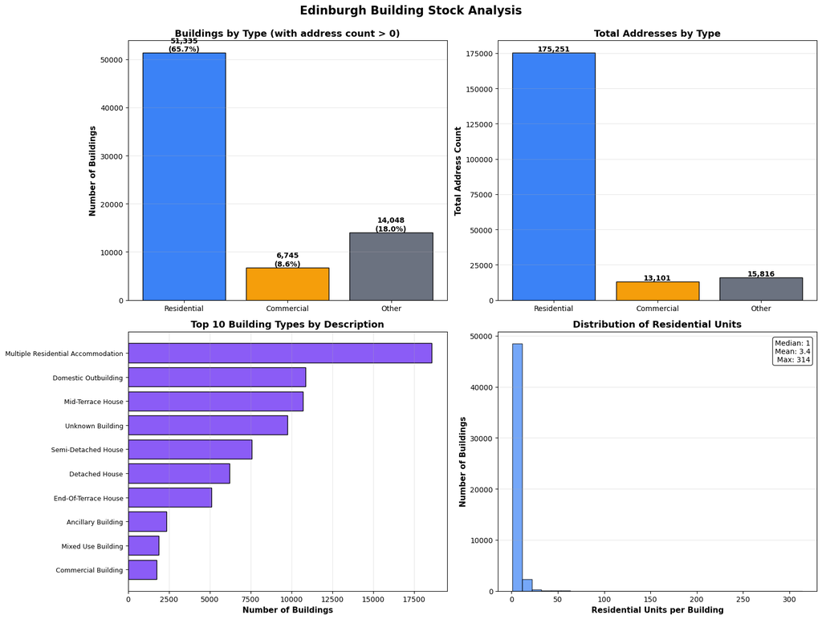

```python
#  BUILDING TYPE ANALYSIS
print("\n" + "="*70)
print("BUILDING TYPE DISTRIBUTION ANALYSIS")
print("="*70)

# 1. Count buildings by address count type
residential_count = (buildings['buildinguse_addresscount_residential'] > 0).sum()
commercial_count = (buildings['buildinguse_addresscount_commercial'] > 0).sum()
other_count = (buildings['buildinguse_addresscount_other'] > 0).sum()

print(f"\n Building Classification by Address Counts:")
print(f"   Residential buildings: {residential_count:,} ({residential_count/len(buildings)*100:.1f}%)")
print(f"   Commercial buildings: {commercial_count:,} ({commercial_count/len(buildings)*100:.1f}%)")
print(f"   Other buildings: {other_count:,} ({other_count/len(buildings)*100:.1f}%)")

# 2. Total address counts
total_residential = buildings['buildinguse_addresscount_residential'].sum()
total_commercial = buildings['buildinguse_addresscount_commercial'].sum()
total_other = buildings['buildinguse_addresscount_other'].sum()

print(f"\n Total Address Counts:")
print(f"   Residential addresses: {int(total_residential):,}")
print(f"   Commercial addresses: {int(total_commercial):,}")
print(f"   Other addresses: {int(total_other):,}")

# 3. Buildings by description (top 15)
print(f"\n Top 15 Building Types by Description:")
description_counts = buildings['description'].value_counts().head(15)
for desc, count in description_counts.items():
    print(f"   {desc}: {count:,} buildings")

# 4. Visualization
fig, axes = plt.subplots(2, 2, figsize=(16, 12))
fig.suptitle('Edinburgh Building Stock Analysis', fontsize=16, fontweight='bold', y=0.995)

# Top Left: Building count by type
ax = axes[0, 0]
type_counts = pd.Series({
    'Residential': residential_count,
    'Commercial': commercial_count,
    'Other': other_count
})
colors = ['#3b82f6', '#f59e0b', '#6b7280']
bars = ax.bar(type_counts.index, type_counts.values, color=colors, edgecolor='black')
ax.set_ylabel('Number of Buildings', fontsize=11, fontweight='bold')
ax.set_title('Buildings by Type (with address count > 0)', fontsize=13, fontweight='bold')
ax.grid(axis='y', alpha=0.3)
# Add value labels
for bar in bars:
    height = bar.get_height()
    ax.text(bar.get_x() + bar.get_width()/2., height,
            f'{int(height):,}\n({height/len(buildings)*100:.1f}%)',
            ha='center', va='bottom', fontsize=10, fontweight='bold')

# Top Right: Total addresses by type
ax = axes[0, 1]
address_counts = pd.Series({
    'Residential': total_residential,
    'Commercial': total_commercial,
    'Other': total_other
})
bars = ax.bar(address_counts.index, address_counts.values, color=colors, edgecolor='black')
ax.set_ylabel('Total Address Count', fontsize=11, fontweight='bold')
ax.set_title('Total Addresses by Type', fontsize=13, fontweight='bold')
ax.grid(axis='y', alpha=0.3)
# Add value labels
for bar in bars:
    height = bar.get_height()
    ax.text(bar.get_x() + bar.get_width()/2., height,
            f'{int(height):,}',
            ha='center', va='bottom', fontsize=10, fontweight='bold')

# Bottom Left: Top 10 building descriptions
ax = axes[1, 0]
top_descriptions = buildings['description'].value_counts().head(10)
ax.barh(range(len(top_descriptions)), top_descriptions.values, color='#8b5cf6', edgecolor='black')
ax.set_yticks(range(len(top_descriptions)))
ax.set_yticklabels(top_descriptions.index, fontsize=9)
ax.set_xlabel('Number of Buildings', fontsize=11, fontweight='bold')
ax.set_title('Top 10 Building Types by Description', fontsize=13, fontweight='bold')
ax.grid(axis='x', alpha=0.3)
ax.invert_yaxis()

# Bottom Right: Residential units distribution
ax = axes[1, 1]
residential_buildings = buildings[buildings['buildinguse_addresscount_residential'] > 0]
unit_counts = residential_buildings['buildinguse_addresscount_residential']
ax.hist(unit_counts, bins=30, color='#3b82f6', edgecolor='black', alpha=0.7)
ax.set_xlabel('Residential Units per Building', fontsize=11, fontweight='bold')
ax.set_ylabel('Number of Buildings', fontsize=11, fontweight='bold')
ax.set_title('Distribution of Residential Units', fontsize=13, fontweight='bold')
ax.grid(axis='y', alpha=0.3)

# Add stats text
median_units = unit_counts.median()
mean_units = unit_counts.mean()
max_units = unit_counts.max()
stats_text = f'Median: {median_units:.0f}\nMean: {mean_units:.1f}\nMax: {int(max_units)}'
ax.text(0.98, 0.97, stats_text, transform=ax.transAxes,
        fontsize=10, verticalalignment='top', horizontalalignment='right',
        bbox=dict(boxstyle='round', facecolor='white', alpha=0.8))

plt.tight_layout()
plt.show()
```

## 📊 Step 4: Load SIMD Deprivation Data

```python
SIMD_PATH = 'SG_SIMD_2020/SG_SIMD_2020.shp'

simd = gpd.read_file(SIMD_PATH, bbox=EDINBURGH_BBOX)

if simd.crs != 'EPSG:4326':
    print(f"Reprojecting from {simd.crs} to EPSG:4326...")
    simd = simd.to_crs('EPSG:4326')

print(f"\n SIMD Columns:")
print(simd.columns.tolist())

simd.head(3)
```

```
Reprojecting from EPSG:27700 to EPSG:4326...

 SIMD Columns:
['DataZone', 'DZName', 'LAName', 'SAPE2017', 'WAPE2017', 'Rankv2', 'Quintilev2', 'Decilev2', 'Vigintilv2', 'Percentv2', 'IncRate', 'IncNumDep', 'IncRankv2', 'EmpRate', 'EmpNumDep', 'EmpRank', 'HlthCIF', 'HlthAlcSR', 'HlthDrugSR', 'HlthSMR', 'HlthDprsPc', 'HlthLBWTPc', 'HlthEmergS', 'HlthRank', 'EduA…
```

|  | DataZone | DZName | LAName | SAPE2017 | WAPE2017 | Rankv2 | Quintilev2 | Decilev2 | Vigintilv2 | Percentv2 | ... | CrimeRate | CrimeRank | HouseNumOC | HouseNumNC | HouseOCrat | HouseNCrat | HouseRank | Shape_Leng | Shape_Area | geometry |
| --- | --- | --- | --- | --- | --- | --- | --- | --- | --- | --- | --- | --- | --- | --- | --- | --- | --- | --- | --- | --- | --- |
| 0 | S01008163 | Wallyford/Whitecraig - 01 | East Lothian | 845 | 535 | 1459 | 2 | 3 | 5 | 21 | ... | 206 | 3321.0 | 95 | 2 | 13% | 0% | 2814.0 | 13871.389077 | 3.554702e+06 | POLYGON ((-3.03307 55.92, -3.03265 55.91875, -... |
| 1 | S01008164 | Wallyford/Whitecraig - 02 | East Lothian | 1692 | 1478 | 3719 | 3 | 6 | 11 | 54 | ... | 308 | 2164.0 | 77 | 8 | 12% | 1% | 2731.0 | 13842.459841 | 4.661550e+06 | POLYGON ((-3.05299 55.93638, -3.05298 55.93631... |
| 2 | S01008165 | Wallyford/Whitecraig - 03 | East Lothian | 1182 | 769 | 5894 | 5 | 9 | 17 | 85 | ... | 130 | 4569.0 | 29 | 0 | 4% | 0% | 6238.0 | 15408.690383 | 7.215650e+06 | POLYGON ((-3.02458 55.9394, -3.02402 55.93921,... |

3 rows × 52 columns

## 🔍 Step 5: Spatial Analysis - Buildings in Flood Zones

Now we'll find which buildings are at risk by doing spatial intersections.

```python
# Create a copy of buildings to store risk info
buildings_risk = buildings.copy()

# Initialize columns
buildings_risk['flood_risk_h'] = False
buildings_risk['flood_risk_m'] = False
buildings_risk['flood_risk_l'] = False

print("High Risk scenario")
# Use the building index to check for matches, drop duplicates
buildings_in_h = gpd.sjoin(buildings_risk, extent_h, predicate='intersects', how='inner')
# Get unique building indices that intersected
at_risk_h_indices = buildings_in_h.index.unique()
buildings_risk.loc[at_risk_h_indices, 'flood_risk_h'] = True
print(f"   {buildings_risk['flood_risk_h'].sum():,} buildings in high risk zone")

print("Medium Risk scenario")
buildings_in_m = gpd.sjoin(buildings_risk, extent_m, predicate='intersects', how='inner')
at_risk_m_indices = buildings_in_m.index.unique()
buildings_risk.loc[at_risk_m_indices, 'flood_risk_m'] = True
print(f"   {buildings_risk['flood_risk_m'].sum():,} buildings in medium risk zone")

print("Low Risk scenario")
buildings_in_l = gpd.sjoin(buildings_risk, extent_l, predicate='intersects', how='inner')
at_risk_l_indices = buildings_in_l.index.unique()
buildings_risk.loc[at_risk_l_indices, 'flood_risk_l'] = True
print(f"   {buildings_risk['flood_risk_l'].sum():,} buildings in low risk zone")

# Any risk
buildings_risk['any_flood_risk'] = (buildings_risk['flood_risk_h'] |
                                     buildings_risk['flood_risk_m'] |
                                     buildings_risk['flood_risk_l'])

print(f"\n Summary:")
print(f"  Total buildings analyzed: {len(buildings_risk):,}")
print(f"  Buildings at any risk of river flooding: {buildings_risk['any_flood_risk'].sum():,}")
print(f"  % at risk of river flooding : {100 * buildings_risk['any_flood_risk'].sum() / len(buildings_risk):.1f}%")
```

```
High Risk scenario
   314 buildings in high risk zone
Medium Risk scenario
   1,395 buildings in medium risk zone
Low Risk scenario
   3,376 buildings in low risk zone

 Summary:
  Total buildings analyzed: 78,099
  Buildings at any risk of river flooding: 3,404
  % at risk of river flooding : 4.4%
```

```python
# Saving complete buildings dataset with flood risk columns

# Save the full buildings_risk dataset (ALL buildings, not just exposed ones)
output_file = 'processed_data/buildings_with_flood_risk.gpkg'

# Simplify geometries slightly for smaller file size
buildings_risk_save = buildings_risk.copy()
buildings_risk_save['geometry'] = buildings_risk_save.geometry.simplify(tolerance=0.00001)

# Save to GeoPackage
buildings_risk_save.to_file(output_file, driver='GPKG', layer='buildings')


print(f"Saved {len(buildings_risk_save):,} buildings (all buildings)")
print(f"\n New columns added: flood_risk_h, flood_risk_m, flood_risk_l, 'any_flood_risk'")
```

```
Saved 78,099 buildings (all buildings)

 New columns added: flood_risk_h, flood_risk_m, flood_risk_l, 'any_flood_risk'
```

```python
buildings_risk = gpd.read_file('processed_data/buildings_with_flood_risk.gpkg')
at_risk = buildings_risk[buildings_risk['any_flood_risk']]
```

## 📏 Step 6: Extract Depth Values (GRIDCODE) , one more spatial join

For each building at risk, we'll extract the flood depth GRIDCODE.

```python
# Extracting depth GRIDCODE values which indicate flood depth bands

def get_max_valid_gridcode(join_df):
    """
    Get max GRIDCODE but prioritize valid depths (1, 2, 3) over No Data (999).
    Logic: Map 999 -> -1, take max, then map -1 back to 999.
    """
    if join_df.empty:
        return pd.Series(dtype=int)

    # Work on a copy to avoid warnings
    temp = join_df.copy()
    # Treat 999 as -1 so it is smaller than 1, 2, 3
    temp.loc[temp['GRIDCODE'] == 999, 'GRIDCODE'] = -1

    # Get max (now 3 > 2 > 1 > -1)
    max_vals = temp.groupby(temp.index)['GRIDCODE'].max()

    # Restore -1 back to 999 (if it was the ONLY value found)
    return max_vals.replace(-1, 999)

# High scenario
print("High scenario depths")
depth_join_h = gpd.sjoin(
    buildings_risk,
    depth_h[['GRIDCODE', 'geometry']],
    predicate='intersects',
    how='left'
)
buildings_risk['gridcode_h'] = get_max_valid_gridcode(depth_join_h)
buildings_risk['gridcode_h'] = buildings_risk['gridcode_h'].fillna(0).astype(int)
print(f"  {(buildings_risk['gridcode_h'] > 0).sum():,} buildings with depth data")

# Medium scenario
print("Medium scenario depths")
depth_join_m = gpd.sjoin(
    buildings_risk,
    depth_m[['GRIDCODE', 'geometry']],
    predicate='intersects',
    how='left'
)
buildings_risk['gridcode_m'] = get_max_valid_gridcode(depth_join_m)
buildings_risk['gridcode_m'] = buildings_risk['gridcode_m'].fillna(0).astype(int)
print(f"  {(buildings_risk['gridcode_m'] > 0).sum():,} buildings with depth data")

# Low scenario
print("Low scenario depths")
depth_join_l = gpd.sjoin(
    buildings_risk,
    depth_l[['GRIDCODE', 'geometry']],
    predicate='intersects',
    how='left'
)
buildings_risk['gridcode_l'] = get_max_valid_gridcode(depth_join_l)
buildings_risk['gridcode_l'] = buildings_risk['gridcode_l'].fillna(0).astype(int)
print(f"  {(buildings_risk['gridcode_l'] > 0).sum():,} buildings with depth data")

# Get maximum GRIDCODE across scenarios (handling 999 correctly)
# Again, treat 999 as -1 so max() picks valid depths across scenarios
cols = ['gridcode_h', 'gridcode_m', 'gridcode_l']
temp_risk = buildings_risk[cols].replace(999, -1)
buildings_risk['max_gridcode'] = temp_risk.max(axis=1).replace(-1, 999).astype(int)

print("\n GRIDCODE Distribution (max grid code):")
at_risk = buildings_risk[buildings_risk['any_flood_risk']]
print(f"  GRIDCODE 1 (< 0.3m): {(at_risk['max_gridcode'] == 1).sum():,} buildings")
print(f"  GRIDCODE 2 (0.3-1.0m): {(at_risk['max_gridcode'] == 2).sum():,} buildings")
print(f"  GRIDCODE 3 (> 1.0m): {(at_risk['max_gridcode'] == 3).sum():,} buildings")
print(f"  GRIDCODE 999 (No data): {(at_risk['max_gridcode'] == 999).sum():,} buildings")
```

```
High scenario depths
  314 buildings with depth data
Medium scenario depths
  1,394 buildings with depth data
Low scenario depths
  3,374 buildings with depth data

 GRIDCODE Distribution (max grid code):
  GRIDCODE 1 (< 0.3m): 1,085 buildings
  GRIDCODE 2 (0.3-1.0m): 1,278 buildings
  GRIDCODE 3 (> 1.0m): 1,001 buildings
  GRIDCODE 999 (No data): 18 buildings
```

```python
# # Testing and validation
# # Compare the counts
# print(f"Buildings with any_flood_risk: {buildings_risk['any_flood_risk'].sum()}")
# print(f"Buildings with gridcode_h > 0: {(buildings_risk['gridcode_h'] > 0).sum()}")
# print(f"Buildings with gridcode_m > 0: {(buildings_risk['gridcode_m'] > 0).sum()}")
# print(f"Buildings with gridcode_l > 0: {(buildings_risk['gridcode_l'] > 0).sum()}")

# # Buildings that are flooded but have no depth data
# flooded_no_depth = buildings_risk[
#     (buildings_risk['any_flood_risk'] == True) &
#     (buildings_risk['max_gridcode'] == 0)
# ]
# print(f"\nBuildings flooded but with GRIDCODE = 0: {len(flooded_no_depth)}")
```

## 💰 Step 7: Calculate Flood Damage Using EU Curves

We'll use EU depth-damage curves to estimate financial losses.

```python
# --- GRIDCODE-BASED DAMAGE FUNCTIONS ---
# Based on SEPA mapping: 1=<0.3m, 2=0.3-1.0m, 3=>1.0m

def get_residential_damage_percent(gridcode):
    """Residential building damage factors by GRIDCODE"""
    if gridcode == 1:  # < 0.3m
        return 0.25
    elif gridcode == 2:  # 0.3m - 1.0m
        return 0.40
    elif gridcode == 3:  # > 1.0m
        return 0.75
    else:  # 0, 999 (No data), etc.
        return 0.0

# def get_commercial_damage_percent(gridcode):
#     """Commercial building damage factors by GRIDCODE"""
#     if gridcode == 1:  # < 0.3m
#         return 0.25
#     elif gridcode == 2:  # 0.3m - 1.0m
#         return 0.45
#     elif gridcode == 3:  # > 1.0m
#         return 0.70
#     else:
#         return 0.0

# def get_other_damage_percent(gridcode):
#     """Other building types (industrial, agricultural, etc.)"""
#     if gridcode == 1:
#         return 0.10
#     elif gridcode == 2:
#         return 0.20
#     elif gridcode == 3:
#         return 0.35
#     else:
#         return 0.0

print("GRIDCODE-based damage functions defined")
```

```
GRIDCODE-based damage functions defined
```

### One more join - Loading the postcode sector shapefile as property prices are avalaible sectorwise

```python
#  Linkingng postcode sectors to buildings

# Load postcode sector boundaries
POSTCODE_SECTORS_PATH = 'GB_Postcodes/PostalSector.shp'  # Update with full path if needed
postcode_sectors = gpd.read_file(POSTCODE_SECTORS_PATH)

# Ensure same CRS
if postcode_sectors.crs != 'EPSG:4326':
    postcode_sectors = postcode_sectors.to_crs('EPSG:4326')

print(f" {len(postcode_sectors):,} postcode sectors")

print(f" Columns: {postcode_sectors.columns.tolist()}")

# Spatial join: buildings → postcode sectors
buildings_with_sector = gpd.sjoin(
    buildings_risk,
    postcode_sectors[['geometry', 'GISSect']],  # Adjust column name based on your shapefile
    how='left',
    predicate='within'
)

# Add to main dataframe
buildings_risk['postcode_sector'] = buildings_with_sector['GISSect']

print(f" total {buildings_risk['postcode_sector'].notna().sum():,} buildings")
print(buildings_risk['postcode_sector'].value_counts().head())
```

```
 9,232 postcode sectors
 Columns: ['SectID', 'RMSect', 'GISSect', 'StrSect', 'PostDist', 'PostArea', 'DistNum', 'SecNum', 'PCCnt', 'AnomCnt', 'RefPC', 'x', 'y', 'Sprawl', 'Locale', 'geometry']
 total 75,716 buildings
postcode_sector
EH 4 2    4236
EH10 5    3897
EH14 1    3507
EH16 5    2906
EH 4 3    2827
Name: count, dtype: int64
```

```python
# Loading property prices by postcode sector

# Load the property price data
price_file = 'Average price of residential units(￡).xlsx'
property_prices = pd.read_excel(price_file)

# Clean up column names
property_prices.columns = ['Postcode_Sector', 'Avg_Price', 'Coverage', 'Source']

# Extract just sector and price
property_prices = property_prices[['Postcode_Sector', 'Avg_Price']].copy()

# Remove any whitespace from postcode sectors
property_prices['Postcode_Sector'] = property_prices['Postcode_Sector'].str.strip()

print(f"Loaded prices for {len(property_prices)} postcode sectors")
print(f"   Price range: £{property_prices['Avg_Price'].min():,.0f} - £{property_prices['Avg_Price'].max():,.0f}")
print(f"   Average: £{property_prices['Avg_Price'].mean():,.0f}")

print("\n Sample sectors with prices:")
print(property_prices.head(10))
```

```
Loaded prices for 26 postcode sectors
   Price range: £152,454 - £1,017,238
   Average: £346,310

 Sample sectors with prices:
  Postcode_Sector  Avg_Price
0          EH 3 5     324250
1          EH 3 6     759500
2          EH 4 1     368824
3          EH 4 2     217100
4          EH 4 3     363639
5          EH 6 4     273549
6          EH 6 5     263122
7          EH 6 6     195766
8          EH 6 7     286965
9          EH 7 4     331842
```

### Merging Avg sector price of property with buildings df

```python
#  Linking property prices to buildings

# Merge property prices with buildings based on postcode_sector
buildings_risk = buildings_risk.merge(
    property_prices,
    left_on='postcode_sector',
    right_on='Postcode_Sector',
    how='left'
)

# Use sector price if available, otherwise NaN
buildings_risk['property_value'] = buildings_risk['Avg_Price']

print(f"Merge complete:")
print(f"   Buildings with sector prices: {buildings_risk['property_value'].notna().sum():,}")
print(f"   Buildings without prices (NaN): {buildings_risk['property_value'].isna().sum():,}")
```

```
Merge complete:
   Buildings with sector prices: 47,468
   Buildings without prices (NaN): 30,631
```

```python
# Calculating damages for EACH scenario (H, M, L)


buildings_risk['residential_units'] = buildings_risk['buildinguse_addresscount_residential'].fillna(0).astype(int)

print(f"Total residential units: {buildings_risk['residential_units'].sum():,}")

def calculate_residential_damage_for_scenario(row, gridcode_col):
    """Calculate damage for a specific scenario (H, M, or L)"""
    # If no property value for this sector, return NaN
    if pd.isna(row['property_value']):
        return np.nan

    # Number of residential units in this building
    residential_count = row['residential_units']

    # If no residential units, no damage
    if residential_count == 0:
        return 0.0

    # Get GRIDCODE for this specific scenario
    gridcode = row[gridcode_col]

    # Get damage percentage
    damage_pct = get_residential_damage_percent(gridcode)

    # Damage per unit
    damage_per_unit = row['property_value'] * damage_pct

    # Total damage for all units in this building
    total_damage = damage_per_unit * residential_count

    return total_damage

# Calculate damage for EACH scenario separately
buildings_risk['damage_h'] = buildings_risk.apply(
    lambda row: calculate_residential_damage_for_scenario(row, 'gridcode_h'),
    axis=1
)

buildings_risk['damage_m'] = buildings_risk.apply(
    lambda row: calculate_residential_damage_for_scenario(row, 'gridcode_m'),
    axis=1
)

buildings_risk['damage_l'] = buildings_risk.apply(
    lambda row: calculate_residential_damage_for_scenario(row, 'gridcode_l'),
    axis=1
)

# Also keep the max damage (worst case) for reference
buildings_risk['damage_max'] = buildings_risk[['damage_h', 'damage_m', 'damage_l']].max(axis=1)

print("\n Damage calculated for all scenarios\n")

# Summary for EACH scenario
at_risk = buildings_risk[buildings_risk['any_flood_risk']]
residential_at_risk = at_risk[at_risk['residential_units'] > 0]


print("RESIDENTIAL DAMAGE SUMMARY BY SCENARIO")


for scenario, col in [('High (1 in 10yr)', 'damage_h'),
                       ('Medium (1 in 200yr)', 'damage_m'),
                       ('Low (1 in 1000yr)', 'damage_l')]:

    # Buildings with damage in this scenario
    with_damage = residential_at_risk[residential_at_risk[col].notna() & (residential_at_risk[col] > 0)]

    print(f"\n {scenario.upper()}")
    print(f"   Buildings with damage: {len(with_damage):,}")
    print(f"   Residential units affected: {with_damage['residential_units'].sum():,}")

    if len(with_damage) > 0:
        print(f"   Total damage: £{with_damage[col].sum():,.0f}")
        print(f"   Average per building: £{with_damage[col].mean():,.0f}")
        print(f"   Average per unit: £{(with_damage[col].sum() / with_damage['residential_units'].sum()):,.0f}")

print("\n" + "=" * 70)

# Detailed breakdown by postcode sector for each scenario
print("\nTOP 5 SECTORS BY DAMAGE - HIGH SCENARIO:")
sector_h = residential_at_risk[residential_at_risk['damage_h'].notna()].groupby('postcode_sector').agg({
    'damage_h': 'sum',
    'residential_units': 'sum'
}).round(0)
sector_h.columns = ['Total_Damage', 'Units']
print(sector_h.sort_values('Total_Damage', ascending=False).head(5))

print("\nTOP 5 SECTORS BY DAMAGE - MEDIUM SCENARIO:")
sector_m = residential_at_risk[residential_at_risk['damage_m'].notna()].groupby('postcode_sector').agg({
    'damage_m': 'sum',
    'residential_units': 'sum'
}).round(0)
sector_m.columns = ['Total_Damage', 'Units']
print(sector_m.sort_values('Total_Damage', ascending=False).head(5))

print("\nTOP 5 SECTORS BY DAMAGE - LOW SCENARIO:")
sector_l = residential_at_risk[residential_at_risk['damage_l'].notna()].groupby('postcode_sector').agg({
    'damage_l': 'sum',
    'residential_units': 'sum'
}).round(0)
sector_l.columns = ['Total_Damage', 'Units']
print(sector_l.sort_values('Total_Damage', ascending=False).head(5))
```

```
Total residential units: 175,251
```

```
 Damage calculated for all scenarios

RESIDENTIAL DAMAGE SUMMARY BY SCENARIO

 HIGH (1 IN 10YR)
   Buildings with damage: 129
   Residential units affected: 1,084
   Total damage: £224,106,512
   Average per building: £1,737,260
   Average per unit: £206,740

 MEDIUM (1 IN 200YR)
   Buildings with damage: 750
   Residential units affected: 3,152
   Total damage: £430,388,953
   Average per building: £573,852
   Average per unit: £136,545

 LOW (1 IN 1000YR)
   Buildings with damage: 2,089
   Residential units affected: 8,183
   Total damage: £1,127,175,171
   Average per building: £539,576
   Average per unit: £137,746

======================================================================

TOP 5 SECTORS BY DAMAGE - HIGH SCENARIO:
                 Total_Damage  Units
postcode_sector
EH 9 3             42298641.0    155
EH 4 3             41982123.0    321
EH 4 1             37988872.0    721
EH 6 5             28746078.0    345
EH12 6             26143017.0     57

TOP 5 SECTORS BY DAMAGE - MEDIUM SCENARIO:
                 Total_Damage  Units
postcode_sector
EH12 5             64618439.0    754
EH 4 1             62644756.0    721
EH 4 3             45982152.0    321
EH 9 3             42298641.0    155
EH11 3             36967490.0   1596

TOP 5 SECTORS BY DAMAGE - LOW SCENARIO:
                 Total_Damage  Units
postcode_sector
EH 7 4            225967810.0    979
EH 3 5            187173312.0    873
EH 4 1            112435996.0    721
EH11 3            109667280.0   1596
EH 4 3             79964216.0    321
```

```python
# Interactive analysis using ipywidgets - same as above but diff


import ipywidgets as widgets
from IPython.display import display, HTML

# Prepare data for all scenarios
residential_at_risk = buildings_risk[
    (buildings_risk['any_flood_risk']) &
    (buildings_risk['residential_units'] > 0)
]

def show_scenario_damage(scenario):
    """Display damage summary for selected scenario"""

    # Map scenario names to column names
    scenario_map = {
        'High (1 in 10 year)': 'h',
        'Medium (1 in 200 year)': 'm',
        'Low (1 in 1000 year)': 'l'
    }

    col_suffix = scenario_map[scenario]
    damage_col = f'damage_{col_suffix}'

    # Filter to buildings with damage in this scenario
    with_damage = residential_at_risk[
        residential_at_risk[damage_col].notna() &
        (residential_at_risk[damage_col] > 0)
    ]

    # Overall summary
    total_damage = with_damage[damage_col].sum()
    total_buildings = len(with_damage)
    total_units = with_damage['residential_units'].sum()

    print("=" * 80)
    print(f" FLOOD DAMAGE ANALYSIS - {scenario.upper()}")
    print("=" * 80)
    print(f"\n OVERALL SUMMARY:")
    print(f"   Total Damage:           £{total_damage:,.0f}")
    print(f"   Buildings Affected:     {total_buildings:,}")
    print(f"   Residential Units:      {total_units:,}")

    if total_units > 0:
        print(f"   Average per Building:   £{total_damage/total_buildings:,.0f}")
        print(f"   Average per Unit:       £{total_damage/total_units:,.0f}")

    # Sector breakdown
    print(f"\n DAMAGE BY POSTCODE SECTOR:\n")

    sector_damage = with_damage[with_damage['postcode_sector'].notna()].groupby('postcode_sector').agg({
        damage_col: 'sum',
        'residential_units': 'sum',
        'osid': 'count'  # Count of buildings
    }).round(0)

    sector_damage.columns = ['Total_Damage_£', 'Units_Affected', 'Buildings']
    sector_damage = sector_damage.sort_values('Total_Damage_£', ascending=False)

    # Add percentage of total damage
    sector_damage['% of Total'] = (sector_damage['Total_Damage_£'] / total_damage * 100).round(1)

    # Format currency
    sector_damage['Total_Damage_£'] = sector_damage['Total_Damage_£'].apply(lambda x: f"£{x:,.0f}")
    sector_damage['% of Total'] = sector_damage['% of Total'].apply(lambda x: f"{x}%")

    display(sector_damage)

    print(f"\nTotal Sectors Affected: {len(sector_damage)}")
    print("=" * 80)

# Create dropdown widget
scenario_dropdown = widgets.Dropdown(
    options=['High (1 in 10 year)', 'Medium (1 in 200 year)', 'Low (1 in 1000 year)'],
    value='Low (1 in 1000 year)',
    description='Scenario:',
    style={'description_width': 'initial'}
)

# Create interactive output
output = widgets.interactive_output(show_scenario_damage, {'scenario': scenario_dropdown})

# Display
display(widgets.VBox([
    widgets.HTML("<h3>🌊 Interactive Flood Damage Analysis</h3>"),
    scenario_dropdown,
    output
]))
```

```
VBox(children=(HTML(value='<h3>🌊 Interactive Flood Damage Analysis</h3>'), Dropdown(description='Scenario:', i…
```

```python
# Testing ignore

print(" Checking for exposed sectors without price data...\n")

# Get buildings at risk with residential units
at_risk_residential = buildings_risk[
    (buildings_risk['any_flood_risk']) &
    (buildings_risk['residential_units'] > 0)
]

# Sectors with flood exposure
exposed_sectors = at_risk_residential['postcode_sector'].dropna().unique()
print(f" Total postcode sectors with flood exposure: {len(exposed_sectors)}")

# Sectors with price data
sectors_with_prices = property_prices['Postcode_Sector'].unique()
print(f" Sectors with price data: {len(sectors_with_prices)}")

# Find sectors exposed but WITHOUT price data
missing_price_sectors = set(exposed_sectors) - set(sectors_with_prices)
print(f"  Sectors exposed but NO price data: {len(missing_price_sectors)}\n")

if len(missing_price_sectors) > 0:
    print("=" * 70)
    print("  SECTORS MISSING PRICE DATA")
    print("=" * 70)

    # Detailed breakdown of missing sectors
    missing_summary = []

    for sector in sorted(missing_price_sectors):
        sector_buildings = at_risk_residential[at_risk_residential['postcode_sector'] == sector]

        missing_summary.append({
            'Sector': sector,
            'Buildings': len(sector_buildings),
            'Residential_Units': sector_buildings['residential_units'].sum(),
            'Buildings_High': sector_buildings['flood_risk_h'].sum(),
            'Buildings_Medium': sector_buildings['flood_risk_m'].sum(),
            'Buildings_Low': sector_buildings['flood_risk_l'].sum()
        })

    missing_df = pd.DataFrame(missing_summary)
    missing_df = missing_df.sort_values('Residential_Units', ascending=False)

    print(missing_df.to_string(index=False))

    print("\n Impact Summary:")
    print(f"   Total buildings affected: {missing_df['Buildings'].sum():,}")
    print(f"   Total residential units affected: {missing_df['Residential_Units'].sum():,}")
    print(f"   % of exposed units without price: {100 * missing_df['Residential_Units'].sum() / at_risk_residential['residential_units'].sum():.1f}%")

else:
    print(" All exposed sectors have price data!")

# Also check: sectors WITH price data but NO exposure (informational)
print("\n" + "=" * 70)
unexposed_with_prices = set(sectors_with_prices) - set(exposed_sectors)
print(f"ℹ Sectors with price data but NOT exposed: {len(unexposed_with_prices)}")
if len(unexposed_with_prices) > 0 and len(unexposed_with_prices) <= 10:
    print(f"   {sorted(unexposed_with_prices)}")
```

```
 Checking for exposed sectors without price data...

 Total postcode sectors with flood exposure: 23
 Sectors with price data: 26
  Sectors exposed but NO price data: 0

 All exposed sectors have price data!

======================================================================
ℹ Sectors with price data but NOT exposed: 3
   ['EH 3 6', 'EH10 6', 'EH13 0']
```

## 📈 Step 8: Visualisations

```python
print("Creating impressive damage visualizations\n")

import matplotlib.pyplot as plt
import seaborn as sns
from matplotlib.patches import Patch
import numpy as np

# Set style
plt.style.use('seaborn-v0_8-darkgrid')
sns.set_palette("husl")

# Filter to buildings with damage estimates
at_risk = buildings_risk[buildings_risk['any_flood_risk']]
with_damage = at_risk[at_risk['damage_max'].notna() & (at_risk['damage_max'] > 0)]

print(f"Creating visualizations for {len(with_damage):,} buildings with damage estimates...")
```

```
Creating impressive damage visualizations

Creating visualizations for 2,096 buildings with damage estimates...
```

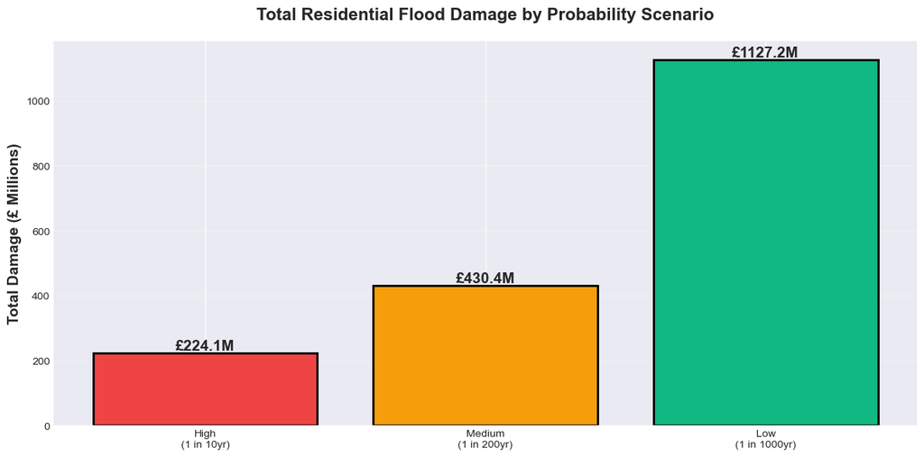

```python
# 1. SCENARIO COMPARISON - Bar Chart
fig, ax = plt.subplots(figsize=(12, 6))

scenarios = {
    'High\n(1 in 10yr)': with_damage['damage_h'].sum(),
    'Medium\n(1 in 200yr)': with_damage['damage_m'].sum(),
    'Low\n(1 in 1000yr)': with_damage['damage_l'].sum()
}

colors = ['#ef4444', '#f59e0b', '#10b981']
bars = ax.bar(scenarios.keys(), [v/1e6 for v in scenarios.values()], color=colors, edgecolor='black', linewidth=2)

# Add value labels on bars
for bar in bars:
    height = bar.get_height()
    ax.text(bar.get_x() + bar.get_width()/2., height,
            f'£{height:.1f}M',
            ha='center', va='bottom', fontsize=14, fontweight='bold')

ax.set_ylabel('Total Damage (£ Millions)', fontsize=14, fontweight='bold')
ax.set_title('Total Residential Flood Damage by Probability Scenario', fontsize=16, fontweight='bold', pad=20)
ax.grid(axis='y', alpha=0.3)
plt.tight_layout()
plt.show()
```

```python
# 2. INTERACTIVE FOLIUM MAP with damage colors
print("Creating interactive damage map")

import folium
from folium.plugins import HeatMap
from branca.colormap import LinearColormap

# Sample if too many buildings (for performance)
MAX_BUILDINGS = 3000
if len(with_damage) > MAX_BUILDINGS:
    map_data = with_damage.sample(n=MAX_BUILDINGS, random_state=42)
    print(f"   Sampling {MAX_BUILDINGS:,} of {len(with_damage):,} buildings for map")
else:
    map_data = with_damage

# Create color map
damage_values = map_data['damage_max'].values
vmin, vmax = damage_values.min(), damage_values.max()
colormap = LinearColormap(
    colors=['#10b981', '#f59e0b', '#ef4444'],
    vmin=vmin,
    vmax=vmax,
    caption='Estimated Damage (£)'
)

# Center on data
center_lat = map_data.geometry.centroid.y.mean()
center_lon = map_data.geometry.centroid.x.mean()

m = folium.Map(
    location=[center_lat, center_lon],
    zoom_start=13,
    tiles='CartoDB positron'
)

# Add buildings with damage-based colors
for idx, row in map_data.iterrows():
    damage = row['damage_max']
    color = colormap(damage)

    # Create popup with details
    popup_html = f"""
    <b>Building Damage Assessment</b><br>
    <hr>
    Residential Units: {int(row['residential_units'])}<br>
    Postcode Sector: {row['postcode_sector']}<br>
    <br>
    <b>Damage by Scenario:</b><br>
    High: £{row['damage_h']:,.0f}<br>
    Medium: £{row['damage_m']:,.0f}<br>
    Low: £{row['damage_l']:,.0f}<br>
    <br>
    <b>Max Damage: £{damage:,.0f}</b>
    """

    folium.GeoJson(
        row['geometry'],
        style_function=lambda x, color=color: {
            'fillColor': color,
            'color': 'black',
            'weight': 0.5,
            'fillOpacity': 0.7
        },
        popup=folium.Popup(popup_html, max_width=300)
    ).add_to(m)

m.save("flood_damage_map.html")
print(" Map saved as flood_damage_map.html")
```

```
Creating interactive damage map
 Map saved as flood_damage_map.html
```

```python
# 4. TOP 10 SECTORS - Interactive Multi-panel comparison
from ipywidgets import interact, Dropdown

def visualize_scenario(scenario='Low (1 in 1000 yr)'):
    """
    Create interactive visualization for selected flood scenario.

    Parameters:
    -----------
    scenario : str
        Flood scenario to visualize: 'High (1 in 10 yr)', 'Medium (1 in 200 yr)', or 'Low (1 in 1000 yr)'
    """
    # Map scenario to damage column
    scenario_map = {
        'High (1 in 10 yr)': {'col': 'damage_h', 'color': '#ef4444', 'label': 'High'},
        'Medium (1 in 200 yr)': {'col': 'damage_m', 'color': '#f59e0b', 'label': 'Medium'},
        'Low (1 in 1000 yr)': {'col': 'damage_l', 'color': '#10b981', 'label': 'Low'}
    }

    selected = scenario_map[scenario]
    damage_col = selected['col']
    scenario_color = selected['color']
    scenario_label = selected['label']

    # Create figure
    fig, axes = plt.subplots(2, 2, figsize=(16, 12))
    fig.suptitle(f'Flood Damage Analysis - {scenario}', fontsize=16, fontweight='bold', y=0.995)

    # Top left: Total damage by sector for selected scenario
    sector_damage = with_damage.groupby('postcode_sector')[damage_col].sum().sort_values(ascending=False).head(10)
    ax = axes[0, 0]
    sector_damage.plot(kind='barh', ax=ax, color=scenario_color, edgecolor='black')
    ax.set_xlabel('Total Damage (£)', fontsize=11, fontweight='bold')
    ax.set_title(f'Top 10 Sectors by Total Damage - {scenario_label} Scenario', fontsize=13, fontweight='bold')
    ax.grid(axis='x', alpha=0.3)

    # Format x-axis labels
    ax.xaxis.set_major_formatter(plt.FuncFormatter(lambda x, p: f'£{x/1e6:.0f}M' if x >= 1e6 else f'£{x/1e3:.0f}K'))

    # Top right: Residential units at risk
    sector_units = with_damage.groupby('postcode_sector')['residential_units'].sum().sort_values(ascending=False).head(10)
    ax = axes[0, 1]
    sector_units.plot(kind='barh', ax=ax, color='#8b5cf6', edgecolor='black')
    ax.set_xlabel('Residential Units', fontsize=11, fontweight='bold')
    ax.set_title('Top 10 Sectors by Units at Risk', fontsize=13, fontweight='bold')
    ax.grid(axis='x', alpha=0.3)

    # Bottom left: Scenario comparison for top sector
    top_sector = sector_damage.index[0]
    top_sector_data = with_damage[with_damage['postcode_sector'] == top_sector]
    scenario_totals = {
        'High': top_sector_data['damage_h'].sum(),
        'Medium': top_sector_data['damage_m'].sum(),
        'Low': top_sector_data['damage_l'].sum()
    }
    ax = axes[1, 0]
    colors = ['#ef4444', '#f59e0b', '#10b981']
    bars = ax.bar(scenario_totals.keys(), [v/1e6 for v in scenario_totals.values()],
                  color=colors, edgecolor='black', alpha=0.8)

    # Highlight the selected scenario
    highlight_idx = {'High (1 in 10 yr)': 0, 'Medium (1 in 200 yr)': 1, 'Low (1 in 1000 yr)': 2}[scenario]
    bars[highlight_idx].set_alpha(1.0)
    bars[highlight_idx].set_linewidth(3)

    ax.set_ylabel('Damage (£ Millions)', fontsize=11, fontweight='bold')
    ax.set_title(f'📊 All Scenarios Comparison - {top_sector}', fontsize=13, fontweight='bold')
    ax.grid(axis='y', alpha=0.3)

    # Bottom right: Damage distribution for selected scenario
    ax = axes[1, 1]
    damage_data = with_damage[with_damage[damage_col] > 0][damage_col] / 1e6  # Convert to millions
    ax.hist(damage_data, bins=30, color=scenario_color, edgecolor='black', alpha=0.7)
    ax.set_xlabel('Damage per Building (£ Millions)', fontsize=11, fontweight='bold')
    ax.set_ylabel('Number of Buildings', fontsize=11, fontweight='bold')
    ax.set_title(f'Damage Distribution - {scenario_label} Scenario', fontsize=13, fontweight='bold')
    ax.grid(axis='y', alpha=0.3)

    # Add summary statistics
    total_damage = with_damage[damage_col].sum()
    total_buildings = len(with_damage[with_damage[damage_col] > 0])
    avg_damage = total_damage / total_buildings if total_buildings > 0 else 0

    stats_text = f'Total Damage: £{total_damage/1e6:.1f}M\\nBuildings: {total_buildings:,}\\nAvg: £{avg_damage/1e3:.0f}K'
    ax.text(0.98, 0.97, stats_text, transform=ax.transAxes,
            fontsize=10, verticalalignment='top', horizontalalignment='right',
            bbox=dict(boxstyle='round', facecolor='white', alpha=0.8))

    plt.tight_layout()
    plt.show()

# Create interactive widget
interact(visualize_scenario,
         scenario=Dropdown(
             options=['High (1 in 10 yr)', 'Medium (1 in 200 yr)', 'Low (1 in 1000 yr)'],
             value='Low (1 in 1000 yr)',
             description='Scenario:',
             style={'description_width': 'initial'}
         ))
```

```
interactive(children=(Dropdown(description='Scenario:', index=2, options=('High (1 in 10 yr)', 'Medium (1 in 2…
```

```
<function __main__.visualize_scenario(scenario='Low (1 in 1000 yr)')>
```

```
 Creating damage intensity heatmap
   Analyzing top 15 sectors by residential units at risk
```

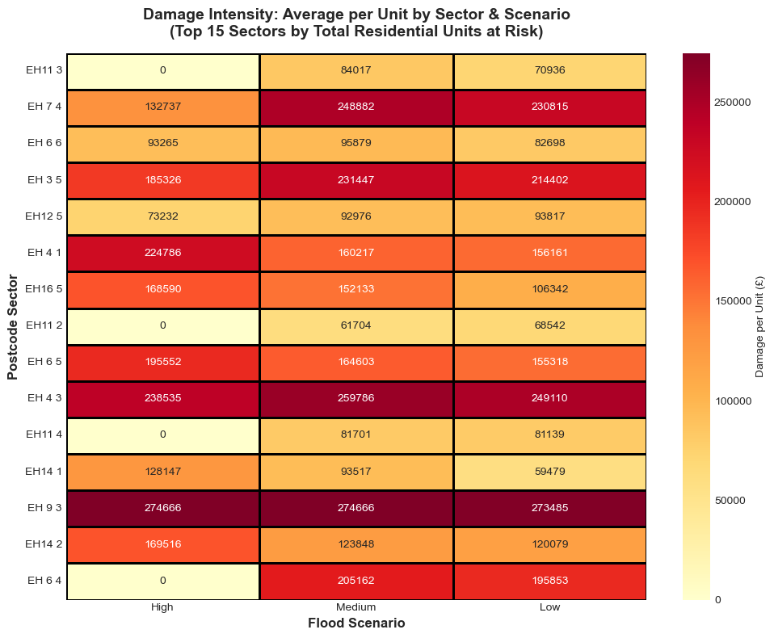

```
 Top 15 Sectors - Units Affected by Scenario:
   Sector     High (1:10)  Med (1:200)  Low (1:1000)
   --------------------------------------------------
   EH11 3            0.0        440.0      1,546.0
   EH 7 4           21.0         21.0        979.0
   EH 6 6          142.0        337.0        916.0
   EH 3 5           58.0         58.0        873.0
   EH12 5            1.0        695.0        752.0
   EH 4 1          169.0        391.0        720.0
   EH16 5           23.0         28.0        377.0
   EH11 2            0.0        116.0        370.0
   EH 6 5          147.0        217.0        345.0
   EH 4 3          176.0        177.0        321.0
   EH11 4            0.0        204.0        224.0
   EH14 1           26.0         44.0        172.0
   EH 9 3          154.0        154.0        155.0
   EH14 2           25.0         99.0        119.0
   EH 6 4            0.0          6.0         72.0

 All visualizations complete!
```

```python
# 5. HEATMAP - Damage per unit by sector and scenario
print("\n Creating damage intensity heatmap")

# Get top 15 sectors by residential units at risk (using Low scenario as it has max extent)
top_sectors = (with_damage.groupby('postcode_sector')['residential_units']
               .sum()
               .sort_values(ascending=False)
               .head(15)
               .index)

print(f"   Analyzing top {len(top_sectors)} sectors by residential units at risk")

# Calculate damage per unit by sector and scenario
# IMPORTANT: Each scenario affects different numbers of units!
sector_analysis = []
for sector in top_sectors:
    sector_data = with_damage[with_damage['postcode_sector'] == sector]

    # Calculate units affected in each scenario (buildings with damage > 0)
    units_h = sector_data[sector_data['damage_h'] > 0]['residential_units'].sum()
    units_m = sector_data[sector_data['damage_m'] > 0]['residential_units'].sum()
    units_l = sector_data[sector_data['damage_l'] > 0]['residential_units'].sum()

    sector_analysis.append({
        'Sector': sector,
        'High': sector_data['damage_h'].sum() / units_h if units_h > 0 else 0,
        'Medium': sector_data['damage_m'].sum() / units_m if units_m > 0 else 0,
        'Low': sector_data['damage_l'].sum() / units_l if units_l > 0 else 0,
        'Units_H': int(units_h),
        'Units_M': int(units_m),
        'Units_L': int(units_l)
    })

heatmap_df = pd.DataFrame(sector_analysis).set_index('Sector')
# Sort by Low scenario units (most comprehensive)
heatmap_df = heatmap_df.sort_values('Units_L', ascending=False)

# Create heatmap (excluding Units columns)
fig, ax = plt.subplots(figsize=(10, 8))
sns.heatmap(heatmap_df[['High', 'Medium', 'Low']], annot=True, fmt='.0f', cmap='YlOrRd',
            linewidths=1, linecolor='black', cbar_kws={'label': 'Damage per Unit (£)'},
            ax=ax)
ax.set_title('Damage Intensity: Average per Unit by Sector & Scenario\n(Top 15 Sectors by Total Residential Units at Risk)',
             fontsize=14, fontweight='bold', pad=15)
ax.set_xlabel('Flood Scenario', fontsize=12, fontweight='bold')
ax.set_ylabel('Postcode Sector', fontsize=12, fontweight='bold')
plt.tight_layout()
plt.show()

# Print summary showing scenario-specific unit counts
print("\n Top 15 Sectors - Units Affected by Scenario:")
print(f"   {'Sector':<10} {'High (1:10)':<12} {'Med (1:200)':<12} {'Low (1:1000)':<12}")
print("   " + "-" * 50)
for idx, row in heatmap_df.iterrows():
    print(f"   {idx:<10} {row['Units_H']:>10,}   {row['Units_M']:>10,}   {row['Units_L']:>10,}")

print("\n All visualizations complete!")
```

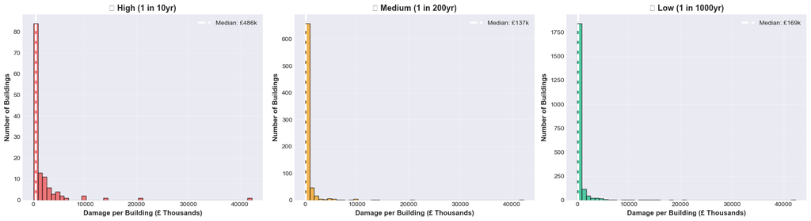

```python
# 3. DAMAGE DISTRIBUTION - Multiple Histograms
fig, axes = plt.subplots(1, 3, figsize=(18, 5))

scenarios = [
    ('High (1 in 10yr)', 'damage_h', '#ef4444'),
    ('Medium (1 in 200yr)', 'damage_m', '#f59e0b'),
    ('Low (1 in 1000yr)', 'damage_l', '#10b981')
]

for ax, (title, col, color) in zip(axes, scenarios):
    data = with_damage[with_damage[col] > 0][col] / 1000  # Convert to thousands

    ax.hist(data, bins=50, color=color, edgecolor='black', alpha=0.7)
    ax.axvline(data.median(), color='white', linestyle='--', linewidth=3, label=f'Median: £{data.median():.0f}k')
    ax.set_xlabel('Damage per Building (£ Thousands)', fontsize=11, fontweight='bold')
    ax.set_ylabel('Number of Buildings', fontsize=11, fontweight='bold')
    ax.set_title(f'💰 {title}', fontsize=13, fontweight='bold')
    ax.legend(fontsize=10)
    ax.grid(alpha=0.3)

plt.tight_layout()
plt.show()
```

## SIMD Flood Damage Analysis

```python
print("Loading SIMD (Scottish Index of Multiple Deprivation) data...\n")

# Load SIMD data
SIMD_PATH = 'SG_SIMD_2020/SG_SIMD_2020.shp'
simd = gpd.read_file(SIMD_PATH)

# Check CRS and reproject if needed
if simd.crs != 'EPSG:4326':
    print(f"Reprojecting SIMD from {simd.crs} to EPSG:4326...")
    simd = simd.to_crs('EPSG:4326')

print(f"Loaded {len(simd):,} SIMD zones")
print(simd.columns.tolist())

# Show sample
simd.head()
```

```
Loading SIMD (Scottish Index of Multiple Deprivation) data...

Reprojecting SIMD from EPSG:27700 to EPSG:4326...
Loaded 6,976 SIMD zones
['DataZone', 'DZName', 'LAName', 'SAPE2017', 'WAPE2017', 'Rankv2', 'Quintilev2', 'Decilev2', 'Vigintilv2', 'Percentv2', 'IncRate', 'IncNumDep', 'IncRankv2', 'EmpRate', 'EmpNumDep', 'EmpRank', 'HlthCIF', 'HlthAlcSR', 'HlthDrugSR', 'HlthSMR', 'HlthDprsPc', 'HlthLBWTPc', 'HlthEmergS', 'HlthRank', 'EduA…
```

|  | DataZone | DZName | LAName | SAPE2017 | WAPE2017 | Rankv2 | Quintilev2 | Decilev2 | Vigintilv2 | Percentv2 | ... | CrimeRate | CrimeRank | HouseNumOC | HouseNumNC | HouseOCrat | HouseNCrat | HouseRank | Shape_Leng | Shape_Area | geometry |
| --- | --- | --- | --- | --- | --- | --- | --- | --- | --- | --- | --- | --- | --- | --- | --- | --- | --- | --- | --- | --- | --- |
| 0 | S01006506 | Culter - 01 | Aberdeen City | 894 | 580 | 4691 | 4 | 7 | 14 | 68 | ... | 125 | 4664.0 | 87 | 10 | 10% | 1% | 3248.0 | 11801.872345 | 4.388802e+06 | POLYGON ((-2.27749 57.09526, -2.27644 57.0952,... |
| 1 | S01006507 | Culter - 02 | Aberdeen City | 793 | 470 | 4862 | 4 | 7 | 14 | 70 | ... | 128 | 4602.0 | 85 | 4 | 10% | 0% | 3486.0 | 2900.406362 | 2.217468e+05 | POLYGON ((-2.27355 57.10448, -2.27333 57.10447... |
| 2 | S01006508 | Culter - 03 | Aberdeen City | 624 | 461 | 5686 | 5 | 9 | 17 | 82 | ... | 130 | 4563.5 | 31 | 8 | 5% | 1% | 5342.0 | 3468.761949 | 2.701948e+05 | POLYGON ((-2.27444 57.1017, -2.27238 57.10045,... |
| 3 | S01006509 | Culter - 04 | Aberdeen City | 537 | 307 | 4332 | 4 | 7 | 13 | 63 | ... | 75 | 5626.0 | 42 | 6 | 7% | 1% | 4394.5 | 1647.461389 | 9.625426e+04 | POLYGON ((-2.26612 57.10132, -2.26599 57.10091... |
| 4 | S01006510 | Culter - 05 | Aberdeen City | 663 | 415 | 3913 | 3 | 6 | 12 | 57 | ... | 168 | 3885.0 | 50 | 7 | 9% | 1% | 3736.0 | 3026.111412 | 1.800766e+05 | POLYGON ((-2.26014 57.10159, -2.26051 57.10133... |

5 rows × 52 columns

```python
# Create building centroids for clean 1:1 mapping with SIMD zones
print("Creating building centroids")
buildings_centroids = buildings_risk.copy()
buildings_centroids['geometry'] = buildings_risk.geometry.centroid

# Spatial join: buildings → SIMD zones
# Make sure buildings_centroids exists (it should from your depth extraction step)
buildings_with_simd = gpd.sjoin(
    buildings_centroids,  # Using centroids for clean 1:1 mapping
    simd[['DataZone', 'DZName', 'LAName', 'Rankv2', 'Quintilev2', 'Decilev2', 'Vigintilv2', 'geometry']],
    how='left',
    predicate='within'
)

# Add SIMD data to buildings_risk
simd_cols = ['DataZone', 'DZName', 'LAName', 'Rankv2', 'Quintilev2', 'Decilev2']

for col in simd_cols:
    if col in buildings_with_simd.columns:
        buildings_risk[col] = buildings_with_simd[col]

print(f"   Linked buildings to SIMD zones")
print(f"   Columns added: {simd_cols}")
print(f"   Buildings matched: {buildings_risk['DataZone'].notna().sum():,}")
print(f"   Buildings unmatched: {buildings_risk['DataZone'].isna().sum():,}")

# Show SIMD quintile distribution (1=most deprived, 5=least deprived)
print(f"\n Buildings by SIMD Quintile:")
print(buildings_risk['Quintilev2'].value_counts().sort_index())

# Show sample
print(buildings_risk[['DataZone', 'DZName', 'Quintilev2', 'residential_units', 'any_flood_risk']].head(10))
```

```
Creating building centroids
   Linked buildings to SIMD zones
   Columns added: ['DataZone', 'DZName', 'LAName', 'Rankv2', 'Quintilev2', 'Decilev2']
   Buildings matched: 78,098
   Buildings unmatched: 1

 Buildings by SIMD Quintile:
Quintilev2
1.0     5467
2.0    11168
3.0     7968
4.0    10620
5.0    42875
Name: count, dtype: int64
    DataZone                        DZName  Quintilev2  residential_units  \
0  S01008466   Parkhead and Sighthill - 03         3.0                  6
1  S01008466   Parkhead and Sighthill - 03         3.0                  2
2  S01008466   Parkhead and Sighthill - 03         3.0                  2
3  S01008470  Broomhouse and Bankhead - 03         1.0                  1
4  S01008471  Broomhouse and Bankhead - 04         1.0                  1
5  S01008470  Broomhouse and Bankhead - 03         1.0                  1
6  S01008471  Broomhouse and Bankhead - 04         1.0                  6
7  S01008471  Broomhouse and Bankhead - 04         1.0                  1
8  S01008471  Broomhouse and Bankhead - 04         1.0                  1
9  S01008471  Broomhouse and Bankhead - 04         1.0                  6

   any_flood_risk
0           False
1           False
2           False
3           False
4           False
5           False
6           False
7           False
8           False
9           False
```

```python
print("\n Analyzing flood risk by deprivation level\n")

# Filter to buildings at risk with residential units
at_risk_residential = buildings_risk[
    (buildings_risk['any_flood_risk']) &
    (buildings_risk['residential_units'] > 0)
]

print("=" * 70)
print("FLOOD RISK BY SIMD QUINTILE")
print("=" * 70)
print("(Quintile 1 = Most Deprived, Quintile 5 = Least Deprived)\n")

for quintile in [1, 2, 3, 4, 5]:
    quintile_data = at_risk_residential[at_risk_residential['Quintilev2'] == quintile]

    if len(quintile_data) > 0:
        # Calculate damages - check if ANY scenario has damage data
        # A building might only be flooded in Medium or Low scenarios!
        with_damage = quintile_data[
            (quintile_data['damage_h'].notna()) |
            (quintile_data['damage_m'].notna()) |
            (quintile_data['damage_l'].notna())
        ]

        print(f"Quintile {quintile}:")
        print(f"   Buildings at risk: {len(quintile_data):,}")
        print(f"   Residential units: {quintile_data['residential_units'].sum():,}")

        if len(with_damage) > 0:
            # Sum each scenario separately (some buildings may not have all scenarios)
            damage_h = quintile_data['damage_h'].sum()  # Will ignore NaN
            damage_m = quintile_data['damage_m'].sum()  # Will ignore NaN
            damage_l = quintile_data['damage_l'].sum()  # Will ignore NaN

            print(f"   Damage (High):   £{damage_h:,.0f}")
            print(f"   Damage (Medium): £{damage_m:,.0f}")
            print(f"   Damage (Low):    £{damage_l:,.0f}")
            print(f"   Buildings with damage data: {len(with_damage):,}")
        else:
            print(f"   Damage: No property price data available")
        print()
```

```
 Analyzing flood risk by deprivation level

======================================================================
FLOOD RISK BY SIMD QUINTILE
======================================================================
(Quintile 1 = Most Deprived, Quintile 5 = Least Deprived)

Quintile 1:
   Buildings at risk: 170
   Residential units: 409
   Damage (High):   £6,008,224
   Damage (Medium): £13,305,520
   Damage (Low):    £27,851,171
   Buildings with damage data: 157

Quintile 2:
   Buildings at risk: 491
   Residential units: 2,174
   Damage (High):   £7,807,424
   Damage (Medium): £42,307,974
   Damage (Low):    £141,478,071
   Buildings with damage data: 468

Quintile 3:
   Buildings at risk: 312
   Residential units: 1,426
   Damage (High):   £34,161,769
   Damage (Medium): £88,479,004
   Damage (Low):    £126,745,783
   Buildings with damage data: 307

Quintile 4:
   Buildings at risk: 168
   Residential units: 1,305
   Damage (High):   £10,693,150
   Damage (Medium): £58,015,918
   Damage (Low):    £216,215,618
   Buildings with damage data: 165

Quintile 5:
   Buildings at risk: 1,067
   Residential units: 3,693
   Damage (High):   £165,435,945
   Damage (Medium): £228,280,537
   Damage (Low):    £614,884,528
   Buildings with damage data: 1,016
```

```
  SIMD Quintile visualisations...
```

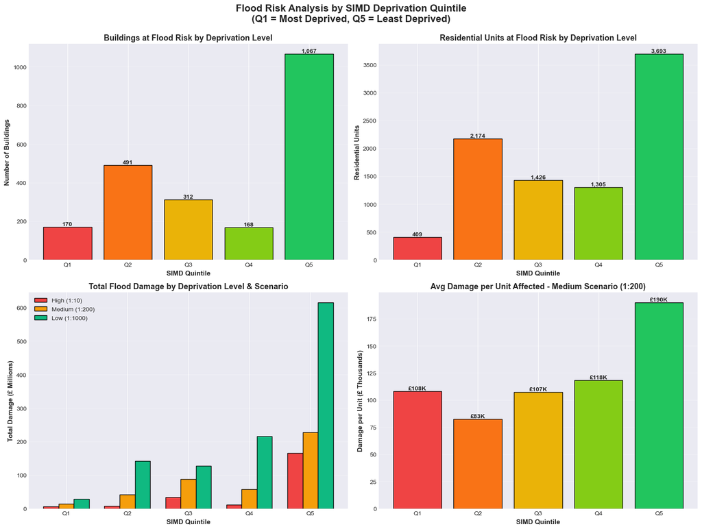

```python
# Visualize Flood Risk by Deprivation Level
print("\n  SIMD Quintile visualisations...\n")

# Prepare data for visualization
quintile_summary = []
for quintile in [1, 2, 3, 4, 5]:
    quintile_data = at_risk_residential[at_risk_residential['Quintilev2'] == quintile]

    if len(quintile_data) > 0:
        # Calculate scenario-specific units (only units actually affected in each scenario)
        units_h = quintile_data[quintile_data['damage_h'] > 0]['residential_units'].sum()
        units_m = quintile_data[quintile_data['damage_m'] > 0]['residential_units'].sum()
        units_l = quintile_data[quintile_data['damage_l'] > 0]['residential_units'].sum()

        # Sum each scenario separately (pandas.sum() ignores NaN)
        quintile_summary.append({
            'Quintile': f'Q{quintile}',
            'Buildings': len(quintile_data),
            'Units_Total': quintile_data['residential_units'].sum(),  # All units at risk (any scenario)
            'Units_H': units_h,  # Units affected in High scenario
            'Units_M': units_m,  # Units affected in Medium scenario
            'Units_L': units_l,  # Units affected in Low scenario
            'Damage_High': quintile_data['damage_h'].sum(),
            'Damage_Medium': quintile_data['damage_m'].sum(),
            'Damage_Low': quintile_data['damage_l'].sum()
        })

df_quintile = pd.DataFrame(quintile_summary)

# Create 2x2 visualization
fig, axes = plt.subplots(2, 2, figsize=(16, 12))
fig.suptitle('Flood Risk Analysis by SIMD Deprivation Quintile\n(Q1 = Most Deprived, Q5 = Least Deprived)',
             fontsize=16, fontweight='bold', y=0.995)

# Color scheme: gradient from red (most deprived) to green (least deprived)
colors = ['#ef4444', '#f97316', '#eab308', '#84cc16', '#22c55e']

# Top Left: Buildings at Risk by Quintile
ax = axes[0, 0]
bars = ax.bar(df_quintile['Quintile'], df_quintile['Buildings'], color=colors, edgecolor='black')
ax.set_ylabel('Number of Buildings', fontsize=11, fontweight='bold')
ax.set_xlabel('SIMD Quintile', fontsize=11, fontweight='bold')
ax.set_title('Buildings at Flood Risk by Deprivation Level', fontsize=13, fontweight='bold')
ax.grid(axis='y', alpha=0.3)
# Add value labels on bars
for bar in bars:
    height = bar.get_height()
    ax.text(bar.get_x() + bar.get_width()/2., height,
            f'{int(height):,}',
            ha='center', va='bottom', fontsize=10, fontweight='bold')

# Top Right: Residential Units at Risk by Quintile (any scenario)
ax = axes[0, 1]
bars = ax.bar(df_quintile['Quintile'], df_quintile['Units_Total'], color=colors, edgecolor='black')
ax.set_ylabel('Residential Units', fontsize=11, fontweight='bold')
ax.set_xlabel('SIMD Quintile', fontsize=11, fontweight='bold')
ax.set_title('Residential Units at Flood Risk by Deprivation Level', fontsize=13, fontweight='bold')
ax.grid(axis='y', alpha=0.3)
# Add value labels on bars
for bar in bars:
    height = bar.get_height()
    ax.text(bar.get_x() + bar.get_width()/2., height,
            f'{int(height):,}',
            ha='center', va='bottom', fontsize=10, fontweight='bold')

# Bottom Left: Total Damage by Quintile (All Scenarios)
ax = axes[1, 0]
x = range(len(df_quintile))
width = 0.25
ax.bar([i - width for i in x], df_quintile['Damage_High']/1e6, width,
       label='High (1:10)', color='#ef4444', edgecolor='black')
ax.bar(x, df_quintile['Damage_Medium']/1e6, width,
       label='Medium (1:200)', color='#f59e0b', edgecolor='black')
ax.bar([i + width for i in x], df_quintile['Damage_Low']/1e6, width,
       label='Low (1:1000)', color='#10b981', edgecolor='black')
ax.set_ylabel('Total Damage (£ Millions)', fontsize=11, fontweight='bold')
ax.set_xlabel('SIMD Quintile', fontsize=11, fontweight='bold')
ax.set_title('Total Flood Damage by Deprivation Level & Scenario', fontsize=13, fontweight='bold')
ax.set_xticks(x)
ax.set_xticklabels(df_quintile['Quintile'])
ax.legend()
ax.grid(axis='y', alpha=0.3)

# Bottom Right: Damage per Unit by Quintile (Medium Scenario)
# Using scenario-specific units (only units actually affected in Medium scenario)
ax = axes[1, 1]
damage_per_unit = df_quintile['Damage_Medium'] / df_quintile['Units_M']
bars = ax.bar(df_quintile['Quintile'], damage_per_unit/1e3, color=colors, edgecolor='black')
ax.set_ylabel('Damage per Unit (£ Thousands)', fontsize=11, fontweight='bold')
ax.set_xlabel('SIMD Quintile', fontsize=11, fontweight='bold')
ax.set_title('Avg Damage per Unit Affected - Medium Scenario (1:200)', fontsize=13, fontweight='bold')
ax.grid(axis='y', alpha=0.3)
# Add value labels on bars
for bar in bars:
    height = bar.get_height()
    if not pd.isna(height):
        ax.text(bar.get_x() + bar.get_width()/2., height,
                f'£{height:.0f}K',
                ha='center', va='bottom', fontsize=10, fontweight='bold')

plt.tight_layout()
plt.show()
```

## SIMD with Damage to identify areas that need help

Should look like below on running it

[figure not shown]

```python
print("🗺️ Creating comprehensive interactive map with SIMD zones + buildings...\n")

import folium
from folium.plugins import MarkerCluster
from branca.colormap import LinearColormap
import json

# Step 1: Aggregate damage by SIMD zone
print("📊 Aggregating damages by SIMD zone...")

simd_damage = at_risk_residential.groupby('DataZone').agg({
    'DZName': 'first',
    'Quintilev2': 'first',
    'residential_units': 'sum',
    'damage_h': 'sum',
    'damage_m': 'sum',
    'damage_l': 'sum',
    'flood_risk_h': 'sum',
    'flood_risk_m': 'sum',
    'flood_risk_l': 'sum'
}).reset_index()

# Count buildings separately
building_counts = at_risk_residential.groupby('DataZone').size().reset_index(name='Buildings')
simd_damage = simd_damage.merge(building_counts, on='DataZone')

simd_damage.columns = ['DataZone', 'ZoneName', 'Quintile', 'Units', 'Damage_H', 'Damage_M', 'Damage_L',
                        'Buildings_H', 'Buildings_M', 'Buildings_L', 'Buildings']

print(f"   {len(simd_damage)} SIMD zones with flood exposure")

# Step 2: Join aggregated data back to SIMD geometries
simd_with_damage = simd.merge(simd_damage, on='DataZone', how='inner')

print(f"   {len(simd_with_damage)} zones matched with geometries")

# Step 3: Create map
center_lat = simd_with_damage.geometry.centroid.y.mean()
center_lon = simd_with_damage.geometry.centroid.x.mean()

m = folium.Map(
    location=[center_lat, center_lon],
    zoom_start=12,
    tiles='CartoDB positron'
)

# Step 4: Add SIMD zone polygons (choropleth by damage)
print("\n🎨 Adding SIMD zone layers...")

# Create colormap for damage
damage_values = simd_with_damage['Damage_H'].dropna()
if len(damage_values) > 0:
    vmin, vmax = damage_values.min(), damage_values.max()
    colormap = LinearColormap(
        colors=['#fff7bc', '#fec44f', '#f03b20', '#bd0026'],
        vmin=vmin,
        vmax=vmax,
        caption='Total Flood Damage (£) - High Scenario'
    )

    # Add zone polygons
    for idx, row in simd_with_damage.iterrows():
        damage = row['Damage_H']

        # Skip zones with no damage data
        if pd.isna(damage):
            continue

        color = colormap(damage)

        # Create detailed popup
        popup_html = f"""
        <div style="width: 300px; font-family: Arial;">
            <h4 style="margin: 0; color: #1f2937;">📍 {row['ZoneName']}</h4>
            <hr style="margin: 5px 0;">

            <b>SIMD Deprivation:</b> Quintile {int(row['Quintile'])}<br>
            <small>({['Most Deprived', 'Highly Deprived', 'Moderately Deprived', 'Less Deprived', 'Least Deprived'][int(row['Quintile'])-1]})</small>

            <h5 style="margin-top: 10px; margin-bottom: 5px; color: #ef4444;">🌊 Flood Exposure</h5>
            <b>Buildings at risk:</b> {int(row['Buildings'])}<br>
            <b>Residential units:</b> {int(row['Units'])}<br>

            <h5 style="margin-top: 10px; margin-bottom: 5px; color: #3b82f6;">💰 Estimated Damage</h5>
            <table style="width: 100%; font-size: 11px;">
                <tr style="background: #f3f4f6;">
                    <td><b>Scenario</b></td>
                    <td><b>Buildings</b></td>
                    <td><b>Damage</b></td>
                </tr>
                <tr>
                    <td>High (1 in 10yr)</td>
                    <td>{int(row['Buildings_H'])}</td>
                    <td>£{row['Damage_H']:,.0f}</td>
                </tr>
                <tr style="background: #f3f4f6;">
                    <td>Medium (1 in 200yr)</td>
                    <td>{int(row['Buildings_M'])}</td>
                    <td>£{row['Damage_M']:,.0f}</td>
                </tr>
                <tr>
                    <td>Low (1 in 1000yr)</td>
                    <td>{int(row['Buildings_L'])}</td>
                    <td>£{row['Damage_L']:,.0f}</td>
                </tr>
            </table>

            <h5 style="margin-top: 10px; margin-bottom: 5px;">📊 Per Unit</h5>
            Avg damage/unit: £{(row['Damage_H'] / row['Units'] if row['Units'] > 0 else 0):,.0f}
        </div>
        """

        folium.GeoJson(
            row['geometry'],
            name=f'SIMD Zones (by damage)',
            style_function=lambda x, color=color: {
                'fillColor': color,
                'color': 'black',
                'weight': 2,
                'fillOpacity': 0.5
            },
            popup=folium.Popup(popup_html, max_width=350)
        ).add_to(m)

    # Add colormap to map
    colormap.add_to(m)

# Step 5: Add individual buildings layer
print("🏠 Adding building markers...")

# Include all buildings (no sampling)
buildings_to_plot = at_risk_residential
print(f"   Plotting all {len(buildings_to_plot):,} buildings")


# Create feature group for buildings
building_layer = folium.FeatureGroup(name='🏢 Individual Buildings', show=False)

# Color by quintile
quintile_colors = {
    1: '#ef4444',
    2: '#f59e0b',
    3: '#fbbf24',
    4: '#84cc16',
    5: '#10b981'
}

# Gridcode description helper
def gridcode_desc(gc):
    if gc == 0:
        return "No flood"
    elif gc == 1:
        return "< 0.3m"
    elif gc == 2:
        return "0.3-1.0m"
    elif gc == 3:
        return "> 1.0m"
    else:
        return "No data"

for idx, row in buildings_to_plot.iterrows():
    if pd.isna(row['Quintilev2']):
        continue

    quintile = int(row['Quintilev2'])
    color = quintile_colors.get(quintile, '#6b7280')

    # Get building description
    building_desc = row['description'] if pd.notna(row.get('description')) else 'Building'
    if pd.isna(building_desc):
        building_desc = 'Building'

    # Format damage values
    damage_h_str = f"£{row['damage_h']:,.0f}" if pd.notna(row['damage_h']) and row['damage_h'] > 0 else '£0 (no price data or not flooded)'
    damage_m_str = f"£{row['damage_m']:,.0f}" if pd.notna(row['damage_m']) and row['damage_m'] > 0 else '£0 (no price data or not flooded)'
    damage_l_str = f"£{row['damage_l']:,.0f}" if pd.notna(row['damage_l']) and row['damage_l'] > 0 else '£0 (no price data or not flooded)'
    damage_max_str = f"£{row['damage_max']:,.0f}" if pd.notna(row['damage_max']) and row['damage_max'] > 0 else '£0'

    # Get flood risk status
    flood_h = "✓ Flooded" if row['flood_risk_h'] else "✗ Not flooded"
    flood_m = "✓ Flooded" if row['flood_risk_m'] else "✗ Not flooded"
    flood_l = "✓ Flooded" if row['flood_risk_l'] else "✗ Not flooded"

    # Get gridcodes
    gridcode_h = int(row['gridcode_h']) if pd.notna(row['gridcode_h']) else 0
    gridcode_m = int(row['gridcode_m']) if pd.notna(row['gridcode_m']) else 0
    gridcode_l = int(row['gridcode_l']) if pd.notna(row['gridcode_l']) else 0

    # Enhanced building popup
    building_popup = f"""
    <div style="width: 280px; font-family: Arial; font-size: 12px;">
        <h4 style="margin: 0 0 5px 0; color: #1f2937;">🏠 {row['DZName']}</h4>
        <hr style="margin: 5px 0;">

        <b>Description:</b> {building_desc}<br>
        <b>SIMD Quintile:</b> {quintile} ({['Most Deprived', 'Highly Deprived', 'Moderate', 'Less Deprived', 'Least Deprived'][quintile-1]})<br>
        <b>Residential Units:</b> {int(row['residential_units'])}<br>
        <b>Postcode Sector:</b> {row.get('postcode_sector', 'N/A')}<br>

        <h5 style="margin: 10px 0 5px 0; color: #ef4444;">🌊 Flood Risk by Scenario</h5>

        <table style="width: 100%; font-size: 11px; border-collapse: collapse;">
            <tr style="background: #f3f4f6; font-weight: bold;">
                <td style="padding: 3px;">Scenario</td>
                <td>Status</td>
                <td>Depth</td>
                <td>Damage</td>
            </tr>
            <tr>
                <td style="padding: 3px;"><b>High</b><br>(1 in 10yr)</td>
                <td>{flood_h}</td>
                <td>{gridcode_desc(gridcode_h)}</td>
                <td>{damage_h_str}</td>
            </tr>
            <tr style="background: #f9fafb;">
                <td style="padding: 3px;"><b>Medium</b><br>(1 in 200yr)</td>
                <td>{flood_m}</td>
                <td>{gridcode_desc(gridcode_m)}</td>
                <td>{damage_m_str}</td>
            </tr>
            <tr>
                <td style="padding: 3px;"><b>Low</b><br>(1 in 1000yr)</td>
                <td>{flood_l}</td>
                <td>{gridcode_desc(gridcode_l)}</td>
                <td>{damage_l_str}</td>
            </tr>
        </table>

        <h5 style="margin: 10px 0 5px 0; color: #3b82f6;">💰 Maximum Damage</h5>
        <b>Worst Case:</b> {damage_max_str}<br>
        <small>(across all scenarios)</small>

        {f'<br><br><small>⚠️ Property value: £{row["property_value"]:,.0f}/unit</small>' if pd.notna(row.get('property_value')) else '<br><br><small>⚠️ No property price data for this sector</small>'}
    </div>
    """

    folium.CircleMarker(
        location=[row.geometry.centroid.y, row.geometry.centroid.x],
        radius=4,
        color='black',
        fillColor=color,
        fillOpacity=0.7,
        weight=1,
        popup=folium.Popup(building_popup, max_width=300)
    ).add_to(building_layer)

building_layer.add_to(m)

# Step 6: Add legend
legend_html = f"""
<div style="position: fixed; bottom: 50px; left: 50px; z-index:9999;
     background-color: white; padding: 15px; border: 3px solid black; border-radius: 8px;
     box-shadow: 0 4px 6px rgba(0,0,0,0.1);">
    <h4 style="margin-top: 0;">🗺️ Map Layers</h4>

    <b>SIMD Zones (Main Layer):</b><br>
    <small>Color intensity = Total flood damage</small><br>
    <small>Click zone for detailed stats</small><br><br>

    <b>Individual Buildings:</b><br>
    <i style="background: #ef4444; width: 14px; height: 14px; display: inline-block; border: 1px solid black; border-radius: 50%;"></i> Q1 (Most Deprived)<br>
    <i style="background: #f59e0b; width: 14px; height: 14px; display: inline-block; border: 1px solid black; border-radius: 50%;"></i> Q2 (Highly Deprived)<br>
    <i style="background: #fbbf24; width: 14px; height: 14px; display: inline-block; border: 1px solid black; border-radius: 50%;"></i> Q3 (Moderate)<br>
    <i style="background: #84cc16; width: 14px; height: 14px; display: inline-block; border: 1px solid black; border-radius: 50%;"></i> Q4 (Less Deprived)<br>
    <i style="background: #10b981; width: 14px; height: 14px; display: inline-block; border: 1px solid black; border-radius: 50%;"></i> Q5 (Least Deprived)<br><br>

    <small><b>Stats Summary:</b></small><br>
    <small>{len(simd_with_damage)} zones exposed</small><br>
    <small>{int(simd_with_damage['Units'].sum()):,} units at risk</small><br>
    <small>£{simd_with_damage['Damage_H'].sum():,.0f} total damage</small>
</div>
"""
m.get_root().html.add_child(folium.Element(legend_html))

# Step 7: Add layer control
folium.LayerControl(position='topright', collapsed=False).add_to(m)

print("\n✅ Interactive map created!")
print(f"📊 Layers:")
print(f"   • SIMD Zone polygons (colored by damage): {len(simd_with_damage)} zones")
print(f"   • Individual buildings (colored by quintile): {len(buildings_to_plot):,} buildings")
print(f"\n💡 Use layer control (top-right) to toggle layers on/off")



m.save("flood_damage_map.html")
print("Map saved to flood_damage_map.html for local viewing.")
```

```
🗺️ Creating comprehensive interactive map with SIMD zones + buildings...

📊 Aggregating damages by SIMD zone...
   69 SIMD zones with flood exposure
   69 zones matched with geometries

🎨 Adding SIMD zone layers...
🏠 Adding building markers...
   Plotting all 2,208 buildings

✅ Interactive map created!
📊 Layers:
   • SIMD Zone polygons (colored by damage): 69 zones
   • Individual buildings (colored by quintile): 2,208 buildings

💡 Use layer control (top-right) to toggle layers on/off
Map saved to flood_damage_map.html for local viewing.
```

```python
# print("🗺️ Creating interactive map with vulnerability filters...\n")

# import folium
# from folium.plugins import MarkerCluster, Search
# from branca.colormap import LinearColormap
# import json

# # Step 1: Aggregate damage by SIMD zone
# print("📊 Aggregating damages by SIMD zone...")

# simd_damage = at_risk_residential.groupby('DataZone').agg({
#     'DZName': 'first',
#     'Quintilev2': 'first',
#     'residential_units': 'sum',
#     'damage_h': 'sum',
#     'damage_m': 'sum',
#     'damage_l': 'sum',
#     'flood_risk_h': 'sum',
#     'flood_risk_m': 'sum',
#     'flood_risk_l': 'sum'
# }).reset_index()

# building_counts = at_risk_residential.groupby('DataZone').size().reset_index(name='Buildings')
# simd_damage = simd_damage.merge(building_counts, on='DataZone')

# simd_damage.columns = ['DataZone', 'ZoneName', 'Quintile', 'Units', 'Damage_H', 'Damage_M', 'Damage_L',
#                         'Buildings_H', 'Buildings_M', 'Buildings_L', 'Buildings']

# # Calculate vulnerability score (higher = more vulnerable)
# simd_damage['Vulnerability_Score'] = (6 - simd_damage['Quintile']) * simd_damage['Units']

# # Join to SIMD geometries
# simd_with_damage = simd.merge(simd_damage, on='DataZone', how='inner')

# print(f"   {len(simd_with_damage)} zones with flood exposure\n")

# # Identify PRIORITY zones (most vulnerable)
# # Criteria: Quintile 1-2 AND high exposure (top 50% of units at risk)
# median_units = simd_with_damage['Units'].median()
# priority_zones = simd_with_damage[
#     (simd_with_damage['Quintile'] <= 2) &
#     (simd_with_damage['Units'] >= median_units)
# ]

# high_deprivation = simd_with_damage[simd_with_damage['Quintile'] <= 2]
# high_exposure = simd_with_damage[simd_with_damage['Units'] >= median_units]

# print(f"🎯 Vulnerability Analysis:")
# print(f"   Priority zones (Q1-2 + high exposure): {len(priority_zones)}")
# print(f"   High deprivation zones (Q1-2): {len(high_deprivation)}")
# print(f"   High exposure zones (≥{median_units:.0f} units): {len(high_exposure)}")

# # Create map
# center_lat = simd_with_damage.geometry.centroid.y.mean()
# center_lon = simd_with_damage.geometry.centroid.x.mean()

# m = folium.Map(
#     location=[center_lat, center_lon],
#     zoom_start=12,
#     tiles='CartoDB positron'
# )

# # Create colormap
# damage_values = simd_with_damage['Damage_H'].dropna()
# vmin, vmax = damage_values.min(), damage_values.max()
# colormap = LinearColormap(
#     colors=['#fff7bc', '#fec44f', '#f03b20', '#bd0026'],
#     vmin=vmin,
#     vmax=vmax,
#     caption='Total Flood Damage (£) - High Scenario'
# )

# # LAYER 1: All SIMD zones with damage (base layer)
# all_zones_layer = folium.FeatureGroup(name='📊 All Zones (by damage)', show=True)

# for idx, row in simd_with_damage.iterrows():
#     if pd.isna(row['Damage_H']):
#         continue

#     color = colormap(row['Damage_H'])

#     popup_html = f"""
#     <div style="width: 300px; font-family: Arial;">
#         <h4 style="margin: 0; color: #1f2937;">📍 {row['ZoneName']}</h4>
#         <hr style="margin: 5px 0;">
#         <b>SIMD Quintile:</b> {int(row['Quintile'])} ({['Most Deprived', 'Highly Deprived', 'Moderate', 'Less Deprived', 'Least Deprived'][int(row['Quintile'])-1]})<br>
#         <b>Buildings at risk:</b> {int(row['Buildings'])}<br>
#         <b>Residential units:</b> {int(row['Units'])}<br>
#         <b>Total damage (High):</b> £{row['Damage_H']:,.0f}<br>
#         <b>Avg damage/unit:</b> £{(row['Damage_H'] / row['Units'] if row['Units'] > 0 else 0):,.0f}
#     </div>
#     """

#     folium.GeoJson(
#         row['geometry'],
#         style_function=lambda x, color=color: {
#             'fillColor': color,
#             'color': 'black',
#             'weight': 1,
#             'fillOpacity': 0.5
#         },
#         popup=folium.Popup(popup_html, max_width=350)
#     ).add_to(all_zones_layer)

# all_zones_layer.add_to(m)

# # LAYER 2: 🚨 PRIORITY zones (High deprivation + High exposure)
# priority_layer = folium.FeatureGroup(name='🚨 PRIORITY: High Deprivation + High Exposure', show=True)

# for idx, row in priority_zones.iterrows():
#     popup_html = f"""
#     <div style="width: 300px; font-family: Arial;">
#         <h4 style="margin: 0; color: #dc2626;">🚨 PRIORITY ZONE</h4>
#         <h5 style="margin: 5px 0; color: #1f2937;">{row['ZoneName']}</h5>
#         <hr style="margin: 5px 0;">
#         <b style="color: #dc2626;">⚠️ High Deprivation + High Flood Exposure</b><br><br>
#         <b>SIMD Quintile:</b> {int(row['Quintile'])} ({['Most Deprived', 'Highly Deprived'][int(row['Quintile'])-1]})<br>
#         <b>Buildings at risk:</b> {int(row['Buildings'])}<br>
#         <b>Residential units:</b> {int(row['Units'])}<br><br>
#         <b>Damage (High):</b> £{row['Damage_H']:,.0f}<br>
#         <b>Damage (Medium):</b> £{row['Damage_M']:,.0f}<br>
#         <b>Damage (Low):</b> £{row['Damage_L']:,.0f}
#     </div>
#     """

#     folium.GeoJson(
#         row['geometry'],
#         style_function=lambda x: {
#             'fillColor': '#dc2626',
#             'color': '#7f1d1d',
#             'weight': 3,
#             'fillOpacity': 0.7,
#             'dashArray': '5, 5'
#         },
#         popup=folium.Popup(popup_html, max_width=350)
#     ).add_to(priority_layer)

# priority_layer.add_to(m)

# # LAYER 3: High Deprivation Only (Q1-2)
# high_dep_layer = folium.FeatureGroup(name='⚠️ High Deprivation (Q1-2)', show=False)

# for idx, row in high_deprivation.iterrows():
#     folium.GeoJson(
#         row['geometry'],
#         style_function=lambda x: {
#             'fillColor': '#f59e0b',
#             'color': '#92400e',
#             'weight': 2,
#             'fillOpacity': 0.6
#         },
#         popup=f"<b>{row['ZoneName']}</b><br>Quintile: {int(row['Quintile'])}<br>Units at risk: {int(row['Units'])}"
#     ).add_to(high_dep_layer)

# high_dep_layer.add_to(m)

# # LAYER 4: High Exposure Only
# high_exp_layer = folium.FeatureGroup(name='🌊 High Flood Exposure', show=False)

# for idx, row in high_exposure.iterrows():
#     folium.GeoJson(
#         row['geometry'],
#         style_function=lambda x: {
#             'fillColor': '#3b82f6',
#             'color': '#1e3a8a',
#             'weight': 2,
#             'fillOpacity': 0.6
#         },
#         popup=f"<b>{row['ZoneName']}</b><br>Units at risk: {int(row['Units'])}<br>Damage: £{row['Damage_H']:,.0f}"
#     ).add_to(high_exp_layer)

# high_exp_layer.add_to(m)

# # Add colormap
# colormap.add_to(m)

# # Enhanced Legend
# legend_html = f"""
# <div style="position: fixed; bottom: 50px; left: 50px; z-index:9999;
#      background-color: white; padding: 15px; border: 3px solid black; border-radius: 8px;
#      box-shadow: 0 4px 6px rgba(0,0,0,0.1); max-width: 280px;">
#     <h4 style="margin-top: 0;">🗺️ Vulnerability Layers</h4>

#     <div style="margin: 10px 0; padding: 8px; background: #fef2f2; border-left: 4px solid #dc2626;">
#         <b>🚨 PRIORITY ZONES</b><br>
#         <small>{len(priority_zones)} zones</small><br>
#         <small>High deprivation (Q1-2) + High flood exposure</small><br>
#         <small><b>{int(priority_zones['Units'].sum()):,} units at risk</b></small>
#     </div>

#     <b>Toggle Layers (use panel top-right):</b>
#     <ul style="font-size: 11px; margin: 5px 0; padding-left: 20px;">
#         <li>📊 All zones (colored by damage)</li>
#         <li>🚨 Priority zones (most vulnerable)</li>
#         <li>⚠️ High deprivation only (Q1-2)</li>
#         <li>🌊 High flood exposure only</li>
#     </ul>

#     <hr style="margin: 10px 0;">
#     <small><b>Total Summary:</b></small><br>
#     <small>{len(simd_with_damage)} zones exposed</small><br>
#     <small>{int(simd_with_damage['Units'].sum()):,} units at risk</small><br>
#     <small>£{simd_with_damage['Damage_H'].sum():,.0f} total damage</small>
# </div>
# """
# m.get_root().html.add_child(folium.Element(legend_html))

# # Add layer control
# folium.LayerControl(position='topright', collapsed=False).add_to(m)

# print("\n✅ Interactive map with vulnerability filters created!")
# print(f"\n🎯 Priority Zones to Focus On:")
# print(f"   {len(priority_zones)} zones need immediate attention")
# print(f"   {int(priority_zones['Units'].sum()):,} residential units affected")
# print(f"   £{priority_zones['Damage_H'].sum():,.0f} total damage")

# # Show top 5 priority zones
# print(f"\n🚨 Top 5 Most Vulnerable Zones:")
# top_priority = priority_zones.sort_values('Damage_H', ascending=False).head(5)
# for idx, row in top_priority.iterrows():
#     print(f"   • {row['ZoneName']}: Q{int(row['Quintile'])}, {int(row['Units'])} units, £{row['Damage_H']:,.0f}")

# m.save("flood_damage_map.html")
# print("Map saved to flood_damage_map.html for local viewing.")
```